# Raveendran Honors Thesis Data

## Overview of the Data Analysis

This project contains data analysis for Rashmi Raveendran’s Honors Thesis, “What’s Good for the Goose May Not Be Good for the Gander: An Analysis of Cardiovascular Disease Risk Comprehension Among South Asian Americans.”

## Introduction and Setup

To begin, the data set was loaded into R using the title ‘sacvd’ to stand for South Asian Cardiovascular Disease.

```r
#Importing Dataset
setwd("C:/Users/RMRAVEE/Desktop/Honors Thesis Data")
sacvd <- read.csv("DOUBLE TAKE Honors Thesis Final Data Spreadsheet.csv")
```

Next, various packages and libraries were loaded into R Studio in order to perform analytic tests and run various analysis models on the data.

```r
#Loading libraries
options(repos = c(CRAN = "https://cran.r-project.org"))
install.packages("tidygeocoder", quiet=TRUE)
library(tidygeocoder)
if (!require(forcats))
install.packages("forcats", dependencies = TRUE)
library(forcats)
install.packages("ggplot2", quiet=TRUE)
library(ggplot2)
install.packages("dplyr")
library(dplyr)
library(tidyr)
install.packages('tidyverse')
library(tidyverse)
install.packages("gt", dependencies = TRUE)
install.packages("gtExtras", dependencies = TRUE)
library(gt)
library(gtExtras)
install.packages("ggpubr")
library(ggpubr)
install.packages("rmarkdown", dependencies = TRUE)
library(rmarkdown)
library(car)
install.packages("logistf", dependencies = TRUE)
library(logistf)
```

The data set was filtered to created a new data set called ‘sacvd100’ (N=53) which marked all the responses that were noted as 100% complete by Qualtrics. The ‘sacvd’ data set and ‘sacvd100’ data sets were later compared to determine if there any notable differences in their distributions.

```r
#Counting # of respondents that have 100% completed marked on Qualtrics
sacvd %>%
  filter(Progress == 100, grepl("United States", Country, ignore.case = TRUE)) %>%
  nrow()
```

```
[1] 53
```

```r
#Creating a subset for this population
sacvd_us_100 <- sacvd %>%
  filter(Progress == 100)
```

## Variable Distributions

The distributions of each variable were produced for either “sacvd” or “sacvd100” to determine which subset of the data set could be used. As both distributions were nearly the same for all variables, the full data set (N=61) “sacvd” was used.

*Age Distribution*

```r
#AGE DISTRIBUTION
summary(sacvd_us_100$Age)
```

```
   Min. 1st Qu.  Median    Mean 3rd Qu.    Max.
   19.0    28.0    44.0    42.7    57.0    73.0
```

```r
summary(sacvd$Age)
```

```
   Min. 1st Qu.  Median    Mean 3rd Qu.    Max.
  19.00   28.00   43.00   42.07   56.00   73.00
```

*Sex Distribution*

```r
#SEX DISTRIBUTION

#SACVD100 Sex Distribution
ggplot(sacvd_us_100, aes(x = Sex, fill = Sex)) +
  geom_bar() +
  geom_text(stat = "count", aes(label = ..count..),
            vjust = -0.3, color = "black", size = 6, fontface = "bold") +  # Adjust text position & bold
  labs(
    title = "Sex Distribution of Respondents in SACVD100",
    x = "Sex",
    y = "Count"
  ) +
  theme_minimal() +
  scale_fill_manual(values = c("darkgray", "lightgray")) +
  theme(
    plot.title = element_text(hjust = 0.5, face = "bold", size = 18),
    axis.title = element_text(size = 16, face = "bold"),
    axis.text = element_text(size = 14),
    legend.title = element_text(size = 14, face = "bold"),
    legend.text = element_text(size = 12)
  )
```

[figure not shown]

```r
#SACVD Sex Distribution
ggplot(sacvd, aes(x = Sex, fill = Sex)) +
  geom_bar() +
  geom_text(stat = "count", aes(label = ..count..),
            vjust = -0.3, color = "black", size = 6, fontface = "bold") +  # Adjust text position & bold
  labs(
    title = "Sex Distribution of Respondents in SACVD",
    x = "Sex",
    y = "Count"
  ) +
  theme_minimal() +
  scale_fill_manual(values = c("darkgray", "lightgray", "purple")) +
  theme(
    plot.title = element_text(hjust = 0.5, face = "bold", size = 18),
    axis.title = element_text(size = 16, face = "bold"),
    axis.text = element_text(size = 14),
    legend.title = element_text(size = 14, face = "bold"),
    legend.text = element_text(size = 12)
  )
```

[figure not shown]

*Geographic Distribution of Respondents in the United States*

```r
#GEOGRAPHIC DISTRIBUTION

#Distribution for SACVD100
location_counts <- sacvd %>%
  filter(Progress == 100, grepl("United States", Country, ignore.case = TRUE)) %>%
  group_by(City, State, Country) %>%
  summarise(count = n(), .groups = 'drop')
location_geo <- location_counts %>%
  mutate(full_address = paste(City, State, Country, sep = ", ")) %>%
  geocode(address = full_address, method = "osm")
```

```
Passing 36 addresses to the Nominatim single address geocoder
```

```
Query completed in: 36.6 seconds
```

```r
us_map <- map_data("state")
ggplot() +
  geom_polygon(data = us_map, aes(x = long, y = lat, group = group),
               fill = "gray80", color = "white") +
  geom_point(data = location_geo, aes(x = long, y = lat, size = count),
             color = "black", alpha = 0.6) +
  scale_size(range = c(3, 12)) +
  labs(
    title = "Geographic Distribution of SACVD100 Survey Responses",
    x = "Longitude", y = "Latitude"
  ) +
  theme_minimal() +
  theme(
    plot.title = element_text(hjust = 0.5, face = "bold", size = 16),  # Centered, bold, large title
    axis.title = element_text(size = 14, face = "bold"),  # Larger, bold axis labels
    axis.text = element_text(size = 12),  # Slightly larger axis text
    legend.title = element_text(size = 13, face = "bold"),  # Bold legend title
    legend.text = element_text(size = 11)  # Adjust legend text size
  )
```

[figure not shown]

```r
#Distribution for SACVD
# Group by location for the full dataset (no filtering)
sacvd_all_counts <- sacvd %>%
  group_by(City, State, Country) %>%
  summarise(total_count = n(), .groups = 'drop')
# Create full address for geocoding
sacvd_all_geo <- sacvd_all_counts %>%
  mutate(full_address = paste(City, State, Country, sep = ", ")) %>%
  geocode(address = full_address, method = "osm")  # OpenStreetMap geocoding
```

```
Passing 39 addresses to the Nominatim single address geocoder
```

```
Query completed in: 39.8 seconds
```

```r
# Load U.S. map data
us_map_all <- map_data("state")
# Create the second plot (for all data points)
ggplot() +
  geom_polygon(data = us_map_all, aes(x = long, y = lat, group = group),
               fill = "gray80", color = "white") +
  geom_point(data = sacvd_all_geo, aes(x = long, y = lat, size = total_count),
             color = "black", alpha = 0.6) +  # Different color for differentiation
  scale_size(range = c(3, 12)) +
  labs(
    title = "Geographic Distribution of All SACVD Survey Responses",
    x = "Longitude", y = "Latitude"
  ) +
  theme_minimal() +
  theme(
    plot.title = element_text(hjust = 0.5, face = "bold", size = 16),
    axis.title = element_text(size = 14, face = "bold"),
    axis.text = element_text(size = 12),
    legend.title = element_text(size = 13, face = "bold"),
    legend.text = element_text(size = 11)
  )
```

[figure not shown]

*Education Level Distribution*

```r
#HIGHEST DEGREE EARNED DISTRIBUTIONS


#Distribution of highest degree earned for SACVD100
sacvd_us_100$HighestDegree <- factor(NA, levels=c ("Nursery school to 8th grade",
                                                   "High school graduate, diploma or the equivalent (for example: GED)",
                                                   "Associate degree",
                                                   "Bachelors degree",
                                                   "Masters degree",
                                                   "Doctorate degree",
                                                   "Other", "I do not have a degree or have not completed any level of school"))
sacvd_us_100$HighestDegree[sacvd_us_100$Highest.Degree.Earned == "Nursery school to 8th grade"] <- "Nursery school to 8th grade"
sacvd_us_100$HighestDegree[sacvd_us_100$Highest.Degree.Earned == "High school graduate, diploma or the equivalent (for example: GED)"] <- "High school graduate, diploma or the equivalent (for example: GED)"
sacvd_us_100$HighestDegree[sacvd_us_100$Highest.Degree.Earned == "Associate degree"] <- "Associate degree"
sacvd_us_100$HighestDegree[sacvd_us_100$Highest.Degree.Earned == "Bachelors degree"] <- "Bachelors degree"
sacvd_us_100$HighestDegree[sacvd_us_100$Highest.Degree.Earned == "Masters degree"] <- "Masters degree"
sacvd_us_100$HighestDegree[sacvd_us_100$Highest.Degree.Earned == "Doctorate degree"] <- "Doctorate degree"
sacvd_us_100$HighestDegree[sacvd_us_100$Highest.Degree.Earned == "Other"] <- "Other"
sacvd_us_100$HighestDegree[sacvd_us_100$Highest.Degree.Earned == "I do not have a degree or have not completed any level of school"] <- "I do not have a degree or have not completed any level of school"
degree_counts_df <- as.data.frame(table(sacvd_us_100$HighestDegree))
ggplot(degree_counts_df, aes(x = reorder(Var1, Freq), y = Freq)) +
  geom_bar(stat = "identity", fill = "white", color = "black") +
  geom_text(aes(label = Freq), hjust = -0.3, size = 5, fontface = "bold") +
  labs(
    title = "Degree Distribution in SACVD100",
    x = "Degree",
    y = "Freq"
  ) +
  coord_flip() +
  theme_minimal() +
  theme(
    plot.title = element_text(hjust = 0.5, face = "bold", size = 16),
    axis.title = element_text(size = 14, face = "bold"),
    axis.text = element_text(size = 12),
    panel.grid.major.y = element_blank(),
    panel.grid.minor = element_blank()
  )
```

[figure not shown]

```r
# Distribution of highest degree earned for SACVD
sacvd$HighestDegree2 <- factor(NA, levels=c("Nursery school to 8th grade",
                                            "High school graduate, diploma or the equivalent (for example: GED)",
                                            "Associate degree",
                                            "Bachelors degree",
                                            "Masters degree",
                                            "Doctorate degree",
                                            "Other",
                                            "I do not have a degree or have not completed any level of school"))
sacvd$HighestDegree2[sacvd$Highest.Degree.Earned == "Nursery school to 8th grade"] <- "Nursery school to 8th grade"
sacvd$HighestDegree2[sacvd$Highest.Degree.Earned == "High school graduate, diploma or the equivalent (for example: GED)"] <- "High school graduate, diploma or the equivalent (for example: GED)"
sacvd$HighestDegree2[sacvd$Highest.Degree.Earned == "Associate degree"] <- "Associate degree"
sacvd$HighestDegree2[sacvd$Highest.Degree.Earned == "Bachelors degree"] <- "Bachelors degree"
sacvd$HighestDegree2[sacvd$Highest.Degree.Earned == "Masters degree"] <- "Masters degree"
sacvd$HighestDegree2[sacvd$Highest.Degree.Earned == "Doctorate degree"] <- "Doctorate degree"
sacvd$HighestDegree2[sacvd$Highest.Degree.Earned == "Other"] <- "Other"
sacvd$HighestDegree2[sacvd$Highest.Degree.Earned == "I do not have a degree or have not completed any level of school"] <- "I do not have a degree or have not completed any level of school"
degree_counts2_df <- as.data.frame(table(sacvd$HighestDegree2))
ggplot(degree_counts2_df, aes(x = reorder(Var1, Freq), y = Freq)) +
  geom_bar(stat = "identity", fill = "white", color = "black") +
  geom_text(aes(label = Freq), hjust = -0.3, size = 5, fontface = "bold") +
  labs(
    title = "Degree Distribution in SACVD",
    x = "Degree",
    y = "Freq"
  ) +
  coord_flip() +
  theme_minimal() +
  theme(
    plot.title = element_text(hjust = 0.5, face = "bold", size = 16),
    axis.title = element_text(size = 14, face = "bold"),
    axis.text = element_text(size = 12),
    panel.grid.major.y = element_blank(),
    panel.grid.minor = element_blank()
  )
```

[figure not shown]

*Religious Affiliation Distribution*

```r
#RELIGIOUS DISTRIBUTIONS

#Distribution by religion for SACVD100
sacvd_us_100$Religion2 <- factor(NA, levels=c ("Christianity", "Islam", "Hinduism", "Buddhism", "Folk religions", "Other", "No religious affiliation"))
sacvd_us_100$Religion2[sacvd_us_100$Religion == "Christianity"] <- "Christianity"
sacvd_us_100$Religion2[sacvd_us_100$Religion == "Islam"] <- "Islam"
sacvd_us_100$Religion2[sacvd_us_100$Religion == "Hinduism"] <- "Hinduism"
sacvd_us_100$Religion2[sacvd_us_100$Religion == "Buddhism"] <- "Buddhism"
sacvd_us_100$Religion2[sacvd_us_100$Religion == "Folk religions"] <- "Folk religions"
sacvd_us_100$Religion2[sacvd_us_100$Religion == "Other"] <- "Other"
sacvd_us_100$Religion2[sacvd_us_100$Religion == "No religious affiliation"] <- "No religious affiliation"
religion_counts2_df <- as.data.frame(table(sacvd_us_100$Religion2))
ggplot(religion_counts2_df, aes(x = reorder(Var1, Freq), y = Freq)) +
  geom_bar(stat = "identity", fill = "white", color = "black") +
  geom_text(aes(label = Freq), hjust = -0.3, size = 5, fontface = "bold") +
  labs(
    title = "Religion Distribution in SACVD100",
    x = "Religion",
    y = "Freq"
  ) +
  coord_flip() +
  theme_minimal() +
  theme(
    plot.title = element_text(hjust = 0.5, face = "bold", size = 16),
    axis.title = element_text(size = 14, face = "bold"),
    axis.text = element_text(size = 12),
    panel.grid.major.y = element_blank(),
    panel.grid.minor = element_blank()
  )
```

[figure not shown]

```r
#Distribution by religion for SACVD
sacvd$Religion3 <- factor(NA, levels=c ("Christianity", "Islam", "Hinduism", "Buddhism", "Folk religions", "Other", "No religious affiliation"))
sacvd$Religion3[sacvd$Religion == "Christianity"] <- "Christianity"
sacvd$Religion3[sacvd$Religion == "Islam"] <- "Islam"
sacvd$Religion3[sacvd$Religion == "Hinduism"] <- "Hinduism"
sacvd$Religion3[sacvd$Religion == "Buddhism"] <- "Buddhism"
sacvd$Religion3[sacvd$Religion == "Folk religions"] <- "Folk religions"
sacvd$Religion3[sacvd$Religion == "Other"] <- "Other"
sacvd$Religion3[sacvd$Religion == "No religious affiliation"] <- "No religious affiliation"
religion_counts3_df <- as.data.frame(table(sacvd$Religion3))
ggplot(religion_counts3_df, aes(x = reorder(Var1, Freq), y = Freq)) +
  geom_bar(stat = "identity", fill = "white", color = "black") +
  geom_text(aes(label = Freq), hjust = -0.3, size = 5, fontface = "bold") +
  labs(
    title = "Religion Distribution in SACVD",
    x = "Religion",
    y = "Freq"
  ) +
  coord_flip() +
  theme_minimal() +
  theme(
    plot.title = element_text(hjust = 0.5, face = "bold", size = 16),
    axis.title = element_text(size = 14, face = "bold"),
    axis.text = element_text(size = 12),
    panel.grid.major.y = element_blank(),
    panel.grid.minor = element_blank()
  )
```

[figure not shown]

*Employment Distribution*

```r
#EMPLOYMENT DISTRIBUTIONS

#Distribution for SACVD100
sacvd_us_100$Employment1 <- factor(NA, levels=c("Employed for wages",
                                                "Self employed",
                                                "Out of work and looking for work",
                                                "Out of work but not currently looking for work",
                                                "A student",
                                                "Military",
                                                "Retired",
                                                "Other",
                                                "Unemployed"))
sacvd_us_100$Employment1[sacvd_us_100$Employment == "Employed for wages"] <- "Employed for wages"
sacvd_us_100$Employment1[sacvd_us_100$Employment == "Self employed"] <- "Self employed"
sacvd_us_100$Employment1[sacvd_us_100$Employment == "Out of work and looking for work"] <- "Out of work\nlooking for work"
sacvd_us_100$Employment1[sacvd_us_100$Employment == "Out of work but not currently looking for work"] <- "Out of work\nnot looking for work"
sacvd_us_100$Employment1[sacvd_us_100$Employment == "A student"] <- "A student"
sacvd_us_100$Employment1[sacvd_us_100$Employment == "Military"] <- "Military"
sacvd_us_100$Employment1[sacvd_us_100$Employment == "Retired"] <- "Retired"
sacvd_us_100$Employment1[sacvd_us_100$Employment == "Other"] <- "Other"
sacvd_us_100$Employment1[sacvd_us_100$Employment == "Unemployed"] <- "Unemployed"
employment_counts1 <- as.data.frame(table(sacvd_us_100$Employment1))
ggplot(employment_counts1, aes(x = reorder(Var1, Freq), y = Freq)) +
  geom_bar(stat = "identity", fill = "white", color = "black") +
  geom_text(aes(label = Freq), hjust = -0.3, size = 5, fontface = "bold") +
  labs(
    title = "Employment Status of Respondents in SACVD100",
    x = "Count",
    y = "Freq"
  ) +
  coord_flip() +
  theme_minimal() +
  theme(
    plot.title = element_text(hjust = 0.5, face = "bold", size = 16),
    axis.title = element_text(size = 14, face = "bold"),
    axis.text = element_text(size = 12),
    panel.grid.major.y = element_blank(),
    panel.grid.minor = element_blank()
  )
```

[figure not shown]

```r
#Distribution for SACVD
sacvd$Employment2 <- factor(NA, levels=c("Employed for wages",
                                         "Self employed",
                                         "Out of work and looking for work",
                                         "Out of work but not currently looking for work",
                                         "A student",
                                         "Military",
                                         "Retired",
                                         "Other",
                                         "Unemployed"))
sacvd$Employment2[sacvd$Employment == "Employed for wages"] <- "Employed for wages"
sacvd$Employment2[sacvd$Employment == "Self employed"] <- "Self employed"
sacvd$Employment2[sacvd$Employment == "Out of work and looking for work"] <- "Out of work\nlooking for work"
sacvd$Employment2[sacvd$Employment == "Out of work but not currently looking for work"] <- "Out of work\nnot looking for work"
sacvd$Employment2[sacvd$Employment == "A student"] <- "A student"
sacvd$Employment2[sacvd$Employment == "Military"] <- "Military"
sacvd$Employment2[sacvd$Employment == "Retired"] <- "Retired"
sacvd$Employment2[sacvd$Employment == "Other"] <- "Other"
sacvd$Employment2[sacvd$Employment == "Unemployed"] <- "Unemployed"
employment_counts2 <- as.data.frame(table(sacvd$Employment2))
ggplot(employment_counts2, aes(x = reorder(Var1, Freq), y = Freq)) +
  geom_bar(stat = "identity", fill = "white", color = "black") +
  geom_text(aes(label = Freq), hjust = -0.3, size = 5, fontface = "bold") +
  labs(
    title = "Employment Status of Respondents in SACVD",
    x = "Count",
    y = "Employment Status"
  ) +
  coord_flip() +  # Makes the bar chart horizontal
  theme_minimal() +
  theme(
    plot.title = element_text(hjust = 0.5, face = "bold", size = 16),
    axis.title = element_text(size = 14, face = "bold"),
    axis.text = element_text(size = 12),
    panel.grid.major.y = element_blank(),
    panel.grid.minor = element_blank()
  )
```

[figure not shown]

*Diet Distribution*

```r
#DIET DISTRIBUTIONS


#Distribution for SACVD100
sacvd_us_100$Diet1 <- factor(NA, levels=c("Vegetarian",
                                          "Vegan",
                                          "Gluten-Free",
                                          "Dairy-Free",
                                          "Low-Carb",
                                          "Keto",
                                          "Paleo",
                                          "Other",
                                          "No specific dietary restrictions"))
sacvd_us_100$Diet1[sacvd_us_100$Diet == "Vegetarian"] <- "Vegetarian"
sacvd_us_100$Diet1[sacvd_us_100$Diet == "Vegan"] <- "Vegan"
sacvd_us_100$Diet1[sacvd_us_100$Diet == "Gluten-Free"] <- "Gluten-Free"
sacvd_us_100$Diet1[sacvd_us_100$Diet == "Dairy-Free"] <- "Dairy-Free"
sacvd_us_100$Diet1[sacvd_us_100$Diet == "Low-Carb"] <- "Low-Carb"
sacvd_us_100$Diet1[sacvd_us_100$Diet == "Keto"] <- "Keto"
sacvd_us_100$Diet1[sacvd_us_100$Diet == "Paleo"] <- "Paleo"
sacvd_us_100$Diet1[sacvd_us_100$Diet == "Other"] <- "Other"
sacvd_us_100$Diet1[sacvd_us_100$Diet == "No specific dietary restrictions"] <- "No specific dietary restrictions"
diet_counts1 <- as.data.frame(table(sacvd_us_100$Diet1))
ggplot(diet_counts1, aes(x = reorder(Var1, Freq), y = Freq)) +
  geom_bar(stat = "identity", fill = "white", color = "black") +
  geom_text(aes(label = Freq), hjust = -0.3, size = 5, fontface = "bold") +
  labs(
    title = "Diets of Respondents in SACVD100",
    x = "Count",
    y = "Diet Type"
  ) +
  coord_flip() +
  theme_minimal() +
  theme(
    plot.title = element_text(hjust = 0.5, face = "bold", size = 16),
    axis.title = element_text(size = 14, face = "bold"),
    axis.text = element_text(size = 12),
    panel.grid.major.y = element_blank(),
    panel.grid.minor = element_blank()
  )
```

[figure not shown]

```r
#Distribution for SACVD
sacvd$Diet2 <- factor(NA, levels=c("Vegetarian",
                                   "Vegan",
                                   "Gluten-Free",
                                   "Dairy-Free",
                                   "Low-Carb",
                                   "Keto",
                                   "Paleo",
                                   "Other",
                                   "No specific dietary restrictions"))
sacvd$Diet2[sacvd$Diet == "Vegetarian"] <- "Vegetarian"
sacvd$Diet2[sacvd$Diet == "Vegan"] <- "Vegan"
sacvd$Diet2[sacvd$Diet == "Gluten-Free"] <- "Gluten-Free"
sacvd$Diet2[sacvd$Diet == "Dairy-Free"] <- "Dairy-Free"
sacvd$Diet2[sacvd$Diet == "Low-Carb"] <- "Low-Carb"
sacvd$Diet2[sacvd$Diet == "Keto"] <- "Keto"
sacvd$Diet2[sacvd$Diet == "Paleo"] <- "Paleo"
sacvd$Diet2[sacvd$Diet == "Other"] <- "Other"
sacvd$Diet2[sacvd$Diet == "No specific dietary restrictions"] <- "No specific dietary restrictions"
diet_counts2 <- as.data.frame(table(sacvd$Diet2))
ggplot(diet_counts2, aes(x = reorder(Var1, Freq), y = Freq)) +
  geom_bar(stat = "identity", fill = "white", color = "black") +
  geom_text(aes(label = Freq), hjust = -0.3, size = 5, fontface = "bold") +
  labs(
    title = "Dietary Preferences of Respondents in SACVD",
    x = "Count",
    y = "Diet Type"
  ) +
  coord_flip() +
  theme_minimal() +
  theme(
    plot.title = element_text(hjust = 0.5, face = "bold", size = 16),
    axis.title = element_text(size = 14, face = "bold"),
    axis.text = element_text(size = 12),
    panel.grid.major.y = element_blank(),
    panel.grid.minor = element_blank()
  )
```

[figure not shown]

*Immigration Status Distribution*

```r
#IMMIGRATION STATUS DISTRIBUTIONS


#Distribution of SACVD100
sacvd_us_100$Immigration.Status1 <- factor(NA, levels=c(
  "Yes, I immigrated to the U.S. (if yes, please write the country from which you immigrated from)",
  "No, I was born in the U.S.",
  "No, I do not live in the U.S.",
  "Other"
))
sacvd_us_100$Immigration.Status1[sacvd_us_100$Immigration.Status ==
                                   "Yes, I immigrated to the U.S. (if yes, please write the country from which you immigrated from)"] <-
  "Yes, I immigrated to the U.S. (if yes, please write the country from which you immigrated from)"
sacvd_us_100$Immigration.Status1[sacvd_us_100$Immigration.Status ==
                                   "No, I was born in the U.S."] <- "No, I was born in the U.S."
sacvd_us_100$Immigration.Status1[sacvd_us_100$Immigration.Status ==
                                   "No, I do not live in the U.S."] <- "No, I do not live in the U.S."
sacvd_us_100$Immigration.Status1[sacvd_us_100$Immigration.Status ==
                                   "Other"] <- "Other"
immigration_counts1 <- as.data.frame(table(sacvd_us_100$Immigration.Status1))

ggplot(immigration_counts1, aes(x = reorder(Var1, Freq), y = Freq)) +
  geom_bar(stat = "identity", fill = "white", color = "black") +
  geom_text(aes(label = Freq), hjust = -0.3, size = 5, fontface = "bold") +
  labs(
    title = "Immigration Status of Respondents in SACVD100",
    x = "Status",
    y = "Freq"
  ) +
  coord_flip() +
  theme_minimal() +
  theme(
    plot.title = element_text(hjust = 0.5, face = "bold", size = 16),
    axis.title = element_text(size = 14, face = "bold"),
    axis.text = element_text(size = 12),
    panel.grid.major.y = element_blank(),
    panel.grid.minor = element_blank()
  )
```

[figure not shown]

```r
#Distribution of SACVD
sacvd$Immigration.Status2 <- factor(NA, levels=c(
  "Yes, I immigrated to the U.S. (if yes, please write the country from which you immigrated from)",
  "No, I was born in the U.S.",
  "No, I do not live in the U.S.",
  "Other"
))
sacvd$Immigration.Status2[sacvd$Immigration.Status ==
                            "Yes, I immigrated to the U.S. (if yes, please write the country from which you immigrated from)"] <-
  "Yes, I immigrated to the U.S. (if yes, please write the country from which you immigrated from)"
sacvd$Immigration.Status2[sacvd$Immigration.Status ==
                            "No, I was born in the U.S."] <- "No, I was born in the U.S."
sacvd$Immigration.Status2[sacvd$Immigration.Status ==
                            "No, I do not live in the U.S."] <- "No, I do not live in the U.S."
sacvd$Immigration.Status2[sacvd$Immigration.Status ==
                            "Other"] <- "Other"
immigration_counts2 <- as.data.frame(table(sacvd$Immigration.Status2))

ggplot(immigration_counts2, aes(x = reorder(Var1, Freq), y = Freq)) +
  geom_bar(stat = "identity", fill = "white", color = "black") +
  geom_text(aes(label = Freq), hjust = -0.3, size = 5, fontface = "bold") +
  labs(
    title = "Immigration Status of Respondents in SACVD",
    x = "Status",
    y = "Freq"
  ) +
  coord_flip() +
  theme_minimal() +
  theme(
    plot.title = element_text(hjust = 0.5, face = "bold", size = 16),
    axis.title = element_text(size = 14, face = "bold"),
    axis.text = element_text(size = 12),
    panel.grid.major.y = element_blank(),
    panel.grid.minor = element_blank()
  )
```

[figure not shown]

*Geographic Distribution by South Asian Country of Origin*

```r
#SOUTH ASIAN COUNTRY OF ORIGIN DISTRIBUTION


#Distribution of SACVD100
south_asia_countries <- c("India", "Pakistan", "Bangladesh", "Sri Lanka", "Nepal", "Bhutan", "Maldives", "Afghanistan")
location_counts_sa <- sacvd_us_100 %>%
  filter(South.Asian.Country.of.Origin %in% south_asia_countries) %>%
  group_by(South.Asian.Country.of.Origin) %>%
  summarise(count = n(), .groups = 'drop')
location_geo_sa <- location_counts_sa %>%
  mutate(full_address = South.Asian.Country.of.Origin) %>%
  geocode(address = full_address, method = "osm")
```

```
Passing 4 addresses to the Nominatim single address geocoder
```

```
Query completed in: 4.1 seconds
```

```r
south_asia_map <- map_data("world") %>%
  filter(region %in% south_asia_countries)
ggplot() +
  geom_polygon(data = south_asia_map, aes(x = long, y = lat, group = group),
               fill = "gray80", color = "white") +
  geom_point(data = location_geo_sa, aes(x = long, y = lat, size = count, color = count),
             alpha = 0.8) +
  scale_size(range = c(3, 15)) +
  scale_color_gradient(low = "yellow", high = "red") +
  labs(
    title = "Geographic Distribution of South Asian Country of Origin",
    x = "Longitude", y = "Latitude", color = "Number of Respondents"
  ) +
  theme_minimal() +
  theme(
    plot.title = element_text(hjust = 0.5, face = "bold", size = 16),
    axis.title = element_text(size = 14, face = "bold"),
    axis.text = element_text(size = 12),
    legend.title = element_text(size = 13, face = "bold"),
    legend.text = element_text(size = 11)
  )
```

[figure not shown]

```r
#Distribution for SACVD
south_asia_countries <- c("India", "Pakistan", "Bangladesh", "Sri Lanka", "Nepal", "Bhutan", "Maldives", "Afghanistan")
location_counts_sa <- sacvd %>%
  filter(South.Asian.Country.of.Origin %in% south_asia_countries) %>%
  group_by(South.Asian.Country.of.Origin) %>%
  summarise(count = n(), .groups = 'drop')
location_geo_sa <- location_counts_sa %>%
  mutate(full_address = South.Asian.Country.of.Origin) %>%
  geocode(address = full_address, method = "osm")
```

```
Passing 4 addresses to the Nominatim single address geocoder
Query completed in: 4.1 seconds
```

```r
south_asia_map <- map_data("world") %>%
  filter(region %in% south_asia_countries)
ggplot() +
  geom_polygon(data = south_asia_map, aes(x = long, y = lat, group = group),
               fill = "gray80", color = "white") +
  geom_point(data = location_geo_sa, aes(x = long, y = lat, size = count, color = count),
             alpha = 0.8) +
  scale_size(range = c(3, 15)) +
  scale_color_gradient(low = "yellow", high = "red") +
  labs(
    title = "Geographic Distribution of South Asian Country of Origin",
    x = "Longitude", y = "Latitude",
    size = "Number of Respondents",
    color = "Number of Respondents"
  ) +
  theme_minimal() +
  theme(
    plot.title = element_text(hjust = 0.5, face = "bold", size = 16),
    axis.title = element_text(size = 14, face = "bold"),
    axis.text = element_text(size = 12),
    legend.title = element_text(size = 13, face = "bold"),
    legend.text = element_text(size = 11)
  )
```

[figure not shown]

*Cardiometabolic Disease Status Distribution*

```r
#CARDIOMETABOLIC DISEASE DISTRIBUTION


#Distribution for SACVD100
sacvd_us_100$Cardiometabolic.Disease <- as.character(sacvd_us_100$Cardiometabolic.Disease)
sacvd_us_100$Cardiometabolic.Disease[is.na(sacvd_us_100$Cardiometabolic.Disease)] <- "I don't know"
sacvd_us_100$Cardiometabolic.Disease <- factor(sacvd_us_100$Cardiometabolic.Disease,
                                               levels = c("Yes", "No", "I don't know"))

ggplot(sacvd_us_100, aes(x = Cardiometabolic.Disease, fill = Cardiometabolic.Disease)) +
  geom_bar() +
  geom_text(stat = "count", aes(label = ..count..),
            vjust = -0.3, color = "black", size = 6, fontface = "bold") +
  labs(
    title = "Cardiometabolic Disease Status of Respondents",
    x = "Cardiometabolic Disease",
    y = "Count"
  ) +
  theme_minimal() +
  scale_fill_manual(values = c("black", "lightgray", "darkgray")) +
  theme(
    plot.title = element_text(hjust = 0.5, face = "bold", size = 18),
    axis.title = element_text(size = 16, face = "bold"),
    axis.text = element_text(size = 14),
    legend.title = element_text(size = 14, face = "bold"),
    legend.text = element_text(size = 12)
  )
```

[figure not shown]

```r
#Distribution for SACVD
sacvd$Cardiometabolic.Disease <- as.character(sacvd$Cardiometabolic.Disease)
sacvd$Cardiometabolic.Disease[is.na(sacvd$Cardiometabolic.Disease)] <- "I don't know"
sacvd$Cardiometabolic.Disease <- factor(sacvd$Cardiometabolic.Disease,
                                        levels = c("Yes", "No", "I don't know"))

ggplot(sacvd, aes(x = Cardiometabolic.Disease, fill = Cardiometabolic.Disease)) +
  geom_bar() +
  geom_text(stat = "count", aes(label = ..count..),
            vjust = -0.3, color = "black", size = 6, fontface = "bold") +
  labs(
    title = "Cardiometabolic Disease Status of Respondents",
    x = "Cardiometabolic Disease",
    y = "Count"
  ) +
  theme_minimal() +
  scale_fill_manual(values = c("black", "lightgray", "darkgray")) +
  theme(
    plot.title = element_text(hjust = 0.5, face = "bold", size = 18),
    axis.title = element_text(size = 16, face = "bold"),
    axis.text = element_text(size = 14),
    legend.title = element_text(size = 14, face = "bold"),
    legend.text = element_text(size = 12)
  )
```

[figure not shown]

*Histograms of Quantitative Variables*

```r
hist(sacvd$Age)
```

[figure not shown]

```r
hist(sacvd$SS1)
```

[figure not shown]

```r
hist(sacvd$SS2)
```

[figure not shown]

```r
hist(sacvd$SS3)
```

[figure not shown]

```r
hist(sacvd$SS4)
```

[figure not shown]

```r
hist(sacvd$SS5)
```

[figure not shown]

```r
hist(sacvd$SS6)
```

[figure not shown]

```r
hist(sacvd$SS7)
```

[figure not shown]

```r
hist(sacvd$SS8)
```

[figure not shown]

```r
hist(sacvd$SS9)
```

[figure not shown]

## Adjusting Variable Distributions

Various variable distributions needed to be adjusted due to the fact that they are skewed in a way that prioritizes one outcome over several others. Sex was not adjusted as there were sufficient counts for each category that was considered.

*Demographic Variables*

*Religious Distribution (Hinduism vs. Other)*

```r
#Changing distribution of religious variable to be Hindu if else
sacvd <- sacvd %>%
  mutate(Religion3Else = case_when(
    Religion3 == "Hinduism" ~ "Hinduism",
    Religion3 %in% c("No Religious Affiliation", "Christianity", "Islam",
                     "Other", "Buddhism", "Folk religions") ~ "Other",
    TRUE ~ NA_character_  # Assigns NA to unexpected values
  ))
```

*Highest Degree Earned Distribution (Graduate Degree vs. Bachelors Degree or Lower)*

```r
#Changing distribution of education variable to be graduate and less than graduate
sacvd <- sacvd %>%
  mutate(HighestDegreeElse = case_when(
    HighestDegree2 %in% c("Masters degree", "Doctorate degree") ~ "Graduate Degree",
    HighestDegree2 %in% c("Bachelors degree",
                         "High school graduate, diploma or the equivalent (for example: GED)",
                         "I do not have a degree or have not completed any level of school",
                         "Other", "Associate degree",
                         "Nursery school to 8th grade") ~ "Bachelors Degree or Lower",
    TRUE ~ NA_character_  # Assigns NA to unexpected values
  ))
```

*Employment Distribution (Employed for Wages vs. Other)*

```r
#Changing employment distribution
sacvd <- sacvd %>%
  mutate(Employment2Else = case_when(
    Employment2 == "Employed for wages" ~ "Employed for wages",
    Employment2 %in% c("A student", "Unemployed", "Other", "Retired",
                       "Military", "Out of work and looking for work",
                       "Out of work but not currently looking for work") ~ "Other",
    TRUE ~ NA_character_  # Assigns NA to unexpected values
  ))
```

*Diet Distribution (No specific dietary restrictions vs. Other)*

```r
#Changing diet distribution
sacvd <- sacvd %>%
  mutate(Diet2Else = case_when(
    Diet2 == "No specific dietary restrictions" ~ "No specific dietary restrictions",
    Diet2 %in% c("Vegan", "Gluten-Free", "Dairy-Free", "Low-Carb",
                 "Keto", "Paleo", "Other") ~ "Other",
    TRUE ~ NA_character_  # Assigns NA to unexpected values
  ))
```

*Immigration Status Distribution (Yes, I immigrated to the U.S. vs. No and Other)*

```r
#Changing immigration status variable
sacvd <- sacvd %>%
  mutate(Immigration.Status2Else = case_when(
    Immigration.Status2 == "Yes, I immigrated to the U.S. (if yes, please write the country from which you immigrated from)" ~
      "Yes, I immigrated to the U.S.",
    Immigration.Status2 %in% c("No, I was born in the U.S.",
                               "No, I do not live in the U.S.",
                               "Other") ~ "No and Other",
    TRUE ~ NA_character_  # Assigns NA to unexpected values
  ))
```

*Cardiometabolic Disease Distribution (Correctly assigning NA values as NA)*

```r
sacvd <- sacvd %>%
  mutate(Cardiometabolic.DiseaseElse = case_when(
    Cardiometabolic.Disease == "Yes" ~ "Yes",
    Cardiometabolic.Disease == "No" ~ "No",
    TRUE ~ NA_character_  # Ensures NA values are properly assigned
  ))
```

*Sliding Scale (‘SS’) Variables*

In order to run a logistic regression and test assumptions, all the sliding scale questions were also converted to be on a scale of 1-6 instead of 0-5.

```r
# Identify all SS# variables
ss_vars <- c("SS1", "SS2", "SS3", "SS4", "SS5", "SS6", "SS7", "SS8", "SS9")

# Create new variables with +1 added
sacvd <- sacvd %>%
  mutate(across(all_of(ss_vars), ~ . + 1, .names = "{.col}_plus1"))
```

Next, ‘SSElse’ variables where every variable is reported as “Low” (Scores 1, 2, and 3) and “High” (Scores 4, 5, 6), to create categorical distributions of each variable in case it was needed for further analysis. Each variable was skewed in slightly different ways, but was grouped into the same categories in order to maintain consistency across variables.

```r
#SS1
sacvd <- sacvd %>%
  mutate(SS1Else = case_when(
    SS1_plus1 %in% c("1", "2", "3") ~ "Low",
    SS1_plus1 %in% c("4", "5", "6") ~ "High",
    TRUE ~ NA_character_  # Ensures unexpected values become NA
  ))
sacvd$SS1Else <- as.factor(sacvd$SS1Else)

#SS2
sacvd <- sacvd %>%
  mutate(SS2Else = case_when(
    SS2_plus1 %in% c("1", "2", "3") ~ "Low",
    SS2_plus1 %in% c("4", "5", "6") ~ "High",
    TRUE ~ NA_character_  # Ensures unexpected values become NA
  ))
sacvd$SS2Else <- as.factor(sacvd$SS2Else)

#SS3
sacvd <- sacvd %>%
  mutate(SS3Else = case_when(
    SS3_plus1 %in% c("1", "2", "3") ~ "Low",
    SS3_plus1 %in% c("4", "5", "6") ~ "High",
    TRUE ~ NA_character_  # Ensures unexpected values become NA
  ))
sacvd$SS3Else <- as.factor(sacvd$SS3Else)

# SS4
sacvd <- sacvd %>%
  mutate(SS4Else = case_when(
    SS4_plus1 %in% c("1", "2", "3") ~ "Low",
    SS4_plus1 %in% c("4", "5", "6") ~ "High",
    TRUE ~ NA_character_
  ))
sacvd$SS4Else <- as.factor(sacvd$SS4Else)

# SS5
sacvd <- sacvd %>%
  mutate(SS5Else = case_when(
    SS5_plus1 %in% c("1", "2", "3") ~ "Low",
    SS5_plus1 %in% c("4", "5", "6") ~ "High",
    TRUE ~ NA_character_
  ))
sacvd$SS5Else <- as.factor(sacvd$SS5Else)

# SS6
sacvd <- sacvd %>%
  mutate(SS6Else = case_when(
    SS6_plus1 %in% c("1", "2", "3") ~ "Low",
    SS6_plus1 %in% c("4", "5", "6") ~ "High",
    TRUE ~ NA_character_
  ))
sacvd$SS6Else <- as.factor(sacvd$SS6Else)

# SS7
sacvd <- sacvd %>%
  mutate(SS7Else = case_when(
    SS7_plus1 %in% c("1", "2", "3") ~ "Low",
    SS7_plus1 %in% c("4", "5", "6") ~ "High",
    TRUE ~ NA_character_
  ))
sacvd$SS7Else <- as.factor(sacvd$SS7Else)

# SS8
sacvd <- sacvd %>%
  mutate(SS8Else = case_when(
    SS8_plus1 %in% c("1", "2", "3") ~ "Low",
    SS8_plus1 %in% c("4", "5", "6") ~ "High",
    TRUE ~ NA_character_
  ))
sacvd$SS8Else <- as.factor(sacvd$SS8Else)

# SS9
sacvd <- sacvd %>%
  mutate(SS9Else = case_when(
    SS9_plus1 %in% c("1", "2", "3") ~ "Low",
    SS9_plus1 %in% c("4", "5", "6") ~ "High",
    TRUE ~ NA_character_
  ))
sacvd$SS9Else <- as.factor(sacvd$SS9Else)
```

## Changing True or False Questions to Accuracy Questions

The following step was re-coding the true or false questions into accuracy questions that marked responses as either “correct” or “incorrect.” Respondents who answered with “I don’t know” were also labeled as “Incorrect” to minimize potential errors in analysis, ensure a binary dependent variable, and because a statement of not knowing the fact is indicative of not being able to answer the question correctly.

*True or False Question Re-coding*

```r
#### TRUE OR FALSE QUESTION RECODING

# TF1
sacvd$TF1accuracy <- NA
sacvd$TF1accuracy[sacvd$TF1 == "FALSE"] <- "Correct"
sacvd$TF1accuracy[sacvd$TF1 == "TRUE" | is.na(sacvd$TF1)] <- "Incorrect"
sacvd$TF1accuracy <- factor(sacvd$TF1accuracy, levels = c("Correct", "Incorrect"))

# TF2
sacvd$TF2accuracy <- NA
sacvd$TF2accuracy[sacvd$TF2 == "TRUE"] <- "Correct"
sacvd$TF2accuracy[sacvd$TF2 == "FALSE" | is.na(sacvd$TF2)] <- "Incorrect"
sacvd$TF2accuracy <- factor(sacvd$TF2accuracy, levels = c("Correct", "Incorrect"))

# TF3
sacvd$TF3accuracy <- NA
sacvd$TF3accuracy[sacvd$TF3 == "TRUE"] <- "Correct"
sacvd$TF3accuracy[sacvd$TF3 == "FALSE" | is.na(sacvd$TF3)] <- "Incorrect"
sacvd$TF3accuracy <- factor(sacvd$TF3accuracy, levels = c("Correct", "Incorrect"))

# TF4
sacvd$TF4accuracy <- NA
sacvd$TF4accuracy[sacvd$TF4 == "FALSE"] <- "Correct"
sacvd$TF4accuracy[sacvd$TF4 == "TRUE" | is.na(sacvd$TF4)] <- "Incorrect"
sacvd$TF4accuracy <- factor(sacvd$TF4accuracy, levels = c("Correct", "Incorrect"))

# TF5
sacvd$TF5accuracy <- NA
sacvd$TF5accuracy[sacvd$TF5 == "TRUE"] <- "Correct"
sacvd$TF5accuracy[sacvd$TF5 == "FALSE" | is.na(sacvd$TF5)] <- "Incorrect"
sacvd$TF5accuracy <- factor(sacvd$TF5accuracy, levels = c("Correct", "Incorrect"))

# TF6
sacvd$TF6accuracy <- NA
sacvd$TF6accuracy[sacvd$TF6 == "FALSE"] <- "Correct"
sacvd$TF6accuracy[sacvd$TF6 == "TRUE" | is.na(sacvd$TF6)] <- "Incorrect"
sacvd$TF6accuracy <- factor(sacvd$TF6accuracy, levels = c("Correct", "Incorrect"))

# TF7
sacvd$TF7accuracy <- NA
sacvd$TF7accuracy[sacvd$TF7 == "TRUE"] <- "Correct"
sacvd$TF7accuracy[sacvd$TF7 == "FALSE" | is.na(sacvd$TF7)] <- "Incorrect"
sacvd$TF7accuracy <- factor(sacvd$TF7accuracy, levels = c("Correct", "Incorrect"))

# TF8
sacvd$TF8accuracy <- NA
sacvd$TF8accuracy[sacvd$TF8 == "FALSE"] <- "Correct"
sacvd$TF8accuracy[sacvd$TF8 == "TRUE" | is.na(sacvd$TF8)] <- "Incorrect"
sacvd$TF8accuracy <- factor(sacvd$TF8accuracy, levels = c("Correct", "Incorrect"))

# TF9
sacvd$TF9accuracy <- NA
sacvd$TF9accuracy[sacvd$TF9 == "FALSE"] <- "Correct"
sacvd$TF9accuracy[sacvd$TF9 == "TRUE" | is.na(sacvd$TF9)] <- "Incorrect"
sacvd$TF9accuracy <- factor(sacvd$TF9accuracy, levels = c("Correct", "Incorrect"))

# TF10
sacvd$TF10accuracy <- NA
sacvd$TF10accuracy[sacvd$TF10 == "FALSE"] <- "Correct"
sacvd$TF10accuracy[sacvd$TF10 == "TRUE" | is.na(sacvd$TF10)] <- "Incorrect"
sacvd$TF10accuracy <- factor(sacvd$TF10accuracy, levels = c("Correct", "Incorrect"))

# TF11
sacvd$TF11accuracy <- NA
sacvd$TF11accuracy[sacvd$TF11 == "TRUE"] <- "Correct"
sacvd$TF11accuracy[sacvd$TF11 == "FALSE" | is.na(sacvd$TF11)] <- "Incorrect"
sacvd$TF11accuracy <- factor(sacvd$TF11accuracy, levels = c("Correct", "Incorrect"))

# TF12
sacvd$TF12accuracy <- NA
sacvd$TF12accuracy[sacvd$TF12 == "TRUE"] <- "Correct"
sacvd$TF12accuracy[sacvd$TF12 == "FALSE" | is.na(sacvd$TF11)] <- "Incorrect"
sacvd$TF12accuracy <- factor(sacvd$TF12accuracy, levels = c("Correct", "Incorrect"))
```

*Creating Total Summary Score Variable*

```r
# Create SummaryScore: Percentage of "Correct" responses out of 12
sacvd <- sacvd %>%
  mutate(SummaryScore = rowMeans(select(., TF1accuracy:TF12accuracy) == "Correct", na.rm = TRUE) * 100)
```

*Pie Chart Accuracy Distributions (Chunk 1: Facet Wrap, Chunk 2: Separate Images)*

```r
# Creating a plot of all the outcomes for accuracy
generate_pie_chart <- function(data, variable, question_number) {
  df <- as.data.frame(table(data[[variable]]))
  df$Percentage <- (df$Freq / sum(df$Freq)) * 100

  ggplot(df, aes(x = "", y = Percentage, fill = Var1)) +
    geom_bar(stat = "identity", width = 1, color = "black") +
    coord_polar(theta = "y") +
    geom_text(aes(label = paste0(round(Percentage, 1), "%")),
              position = position_stack(vjust = 0.5), size = 10, fontface = "bold") +  # Smaller text
    labs(
      title = paste0("Question ", question_number),
      fill = "Response"
    ) +
    theme_minimal() +
    theme(
      plot.title = element_text(hjust = 0.5, face = "bold", size = 12),  # Smaller title
      legend.position = "none",  # Remove individual legends
      axis.title = element_blank(),
      axis.text = element_blank(),
      panel.grid = element_blank()
    ) +
    scale_fill_manual(values = c("Correct" = "lightgreen", "Incorrect" = "coral"))  # Removed "Don't Know"
}

# Generate plots for each question
tf1_plot <- generate_pie_chart(sacvd, "TF1accuracy", 1)
tf2_plot <- generate_pie_chart(sacvd, "TF2accuracy", 2)
tf3_plot <- generate_pie_chart(sacvd, "TF3accuracy", 3)
tf4_plot <- generate_pie_chart(sacvd, "TF4accuracy", 4)
tf5_plot <- generate_pie_chart(sacvd, "TF5accuracy", 5)
tf6_plot <- generate_pie_chart(sacvd, "TF6accuracy", 6)
tf7_plot <- generate_pie_chart(sacvd, "TF7accuracy", 7)
tf8_plot <- generate_pie_chart(sacvd, "TF8accuracy", 8)
tf9_plot <- generate_pie_chart(sacvd, "TF9accuracy", 9)
tf10_plot <- generate_pie_chart(sacvd, "TF10accuracy", 10)
tf11_plot <- generate_pie_chart(sacvd, "TF11accuracy", 11)
tf12_plot <- generate_pie_chart(sacvd, "TF12accuracy", 12)

# Update legend to include only "Correct" and "Incorrect"
legend_plot <- ggplot(data.frame(x = c(1,2)), aes(x, x, fill = factor(x, labels = c("Correct", "Incorrect")))) +
  geom_bar(stat = "identity") +
  scale_fill_manual(values = c("lightgreen", "coral")) +  # Removed "Don't Know"
  theme_void() +
  theme(legend.position = "bottom",
        legend.title = element_text(size = 14, face = "bold"),  # Adjust legend size
        legend.text = element_text(size = 12)) +
  labs(fill = "Response Type")

# Arrange all plots
ggarrange(tf1_plot, tf2_plot, tf3_plot, tf4_plot,
          tf5_plot, tf6_plot, tf7_plot, tf8_plot,
          tf9_plot, tf10_plot, tf11_plot, tf12_plot,
          legend_plot,
          ncol = 4, nrow = 4, heights = c(1, 1, 1, 0.3),
          widths = c(1, 1, 1, 1.6))  # Increase last column width
```

[figure not shown]

```r
# Save the figure
ggsave("TF Accuracy Pie Charts.png", width = 20, height = 10, dpi = 600, bg = "white")
```

```r
# Define file path
output_dir <- "C:/Users/RMRAVEE/Desktop/Honors Thesis Data/"

# Generate and save each pie chart
ggsave(filename = paste0(output_dir, "pie_chart_TF1accuracy.png"), plot = tf1_plot, width = 5, height = 5, dpi = 300)
ggsave(filename = paste0(output_dir, "pie_chart_TF2accuracy.png"), plot = tf2_plot, width = 5, height = 5, dpi = 300)
ggsave(filename = paste0(output_dir, "pie_chart_TF3accuracy.png"), plot = tf3_plot, width = 5, height = 5, dpi = 300)
ggsave(filename = paste0(output_dir, "pie_chart_TF4accuracy.png"), plot = tf4_plot, width = 5, height = 5, dpi = 300)
ggsave(filename = paste0(output_dir, "pie_chart_TF5accuracy.png"), plot = tf5_plot, width = 5, height = 5, dpi = 300)
ggsave(filename = paste0(output_dir, "pie_chart_TF6accuracy.png"), plot = tf6_plot, width = 5, height = 5, dpi = 300)
ggsave(filename = paste0(output_dir, "pie_chart_TF7accuracy.png"), plot = tf7_plot, width = 5, height = 5, dpi = 300)
ggsave(filename = paste0(output_dir, "pie_chart_TF8accuracy.png"), plot = tf8_plot, width = 5, height = 5, dpi = 300)
ggsave(filename = paste0(output_dir, "pie_chart_TF9accuracy.png"), plot = tf9_plot, width = 5, height = 5, dpi = 300)
ggsave(filename = paste0(output_dir, "pie_chart_TF10accuracy.png"), plot = tf10_plot, width = 5, height = 5, dpi = 300)
ggsave(filename = paste0(output_dir, "pie_chart_TF11accuracy.png"), plot = tf11_plot, width = 5, height = 5, dpi = 300)
ggsave(filename = paste0(output_dir, "pie_chart_TF12accuracy.png"), plot = tf12_plot, width = 5, height = 5, dpi = 300)
```

*Making a Table for Accuracy Distribution*

**Table 9. Accuracy for True or False Survey Questions**

Question 1 (False): Fat is stored predominantly in the liver for all individuals.

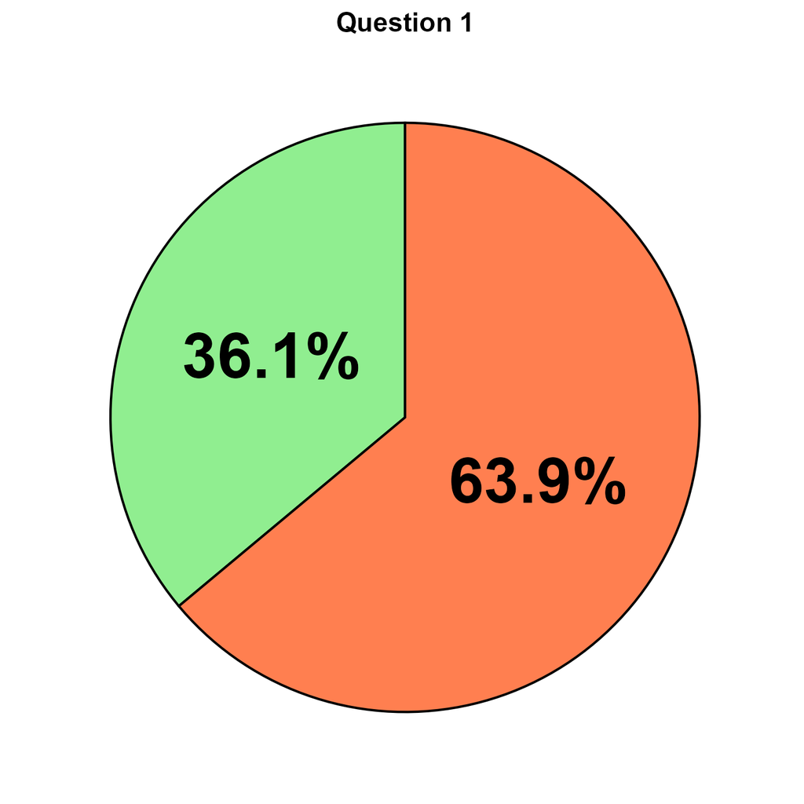

Question 2 (True): South Asians account for 60 percent of the world's heart disease patients.

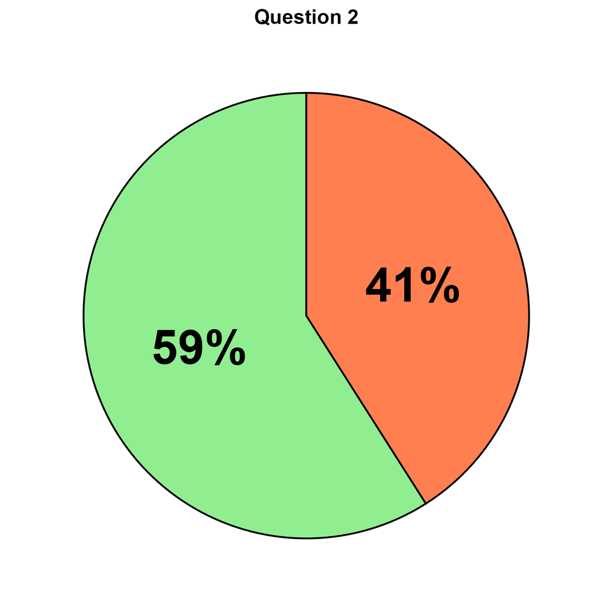

Question 3 (True): Lipoprotein(a) is a type of fat in the body that's a genetically determined risk factor for heart disease and stroke.

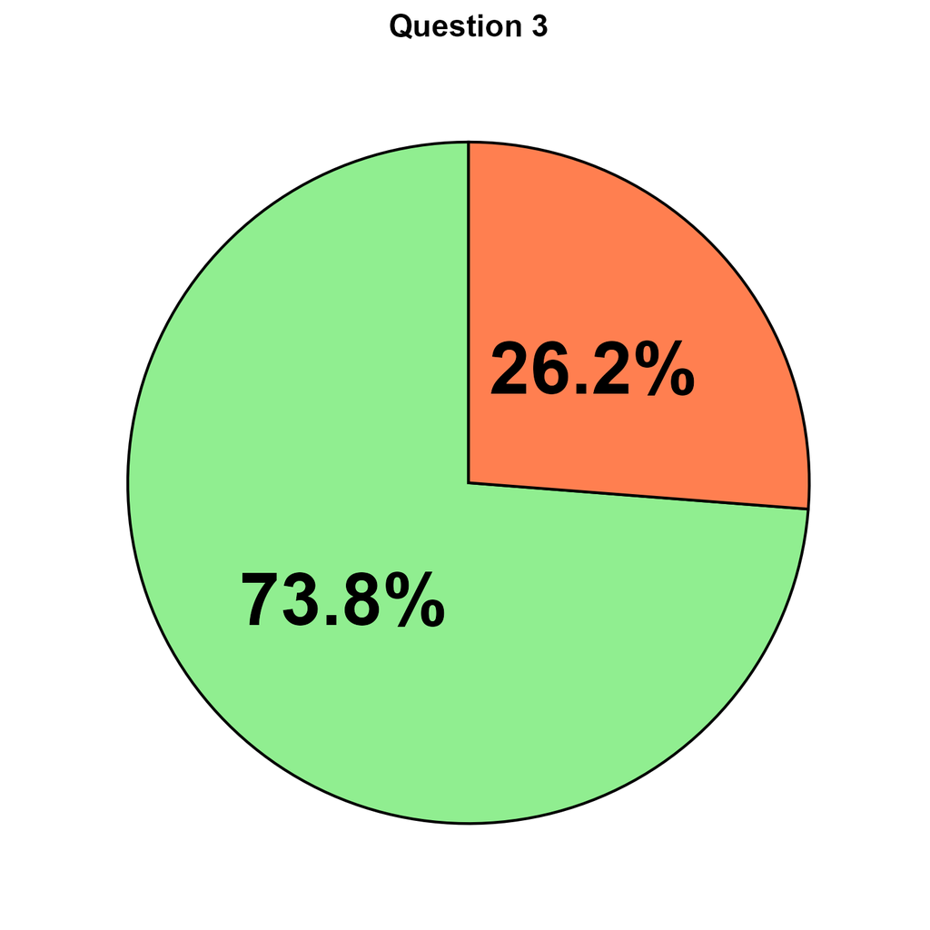

Question 4 (False): South Asians have higher levels of fat that increase heart disease risk compared to Caucasians, but have lower levels of this fat compared to other groups.

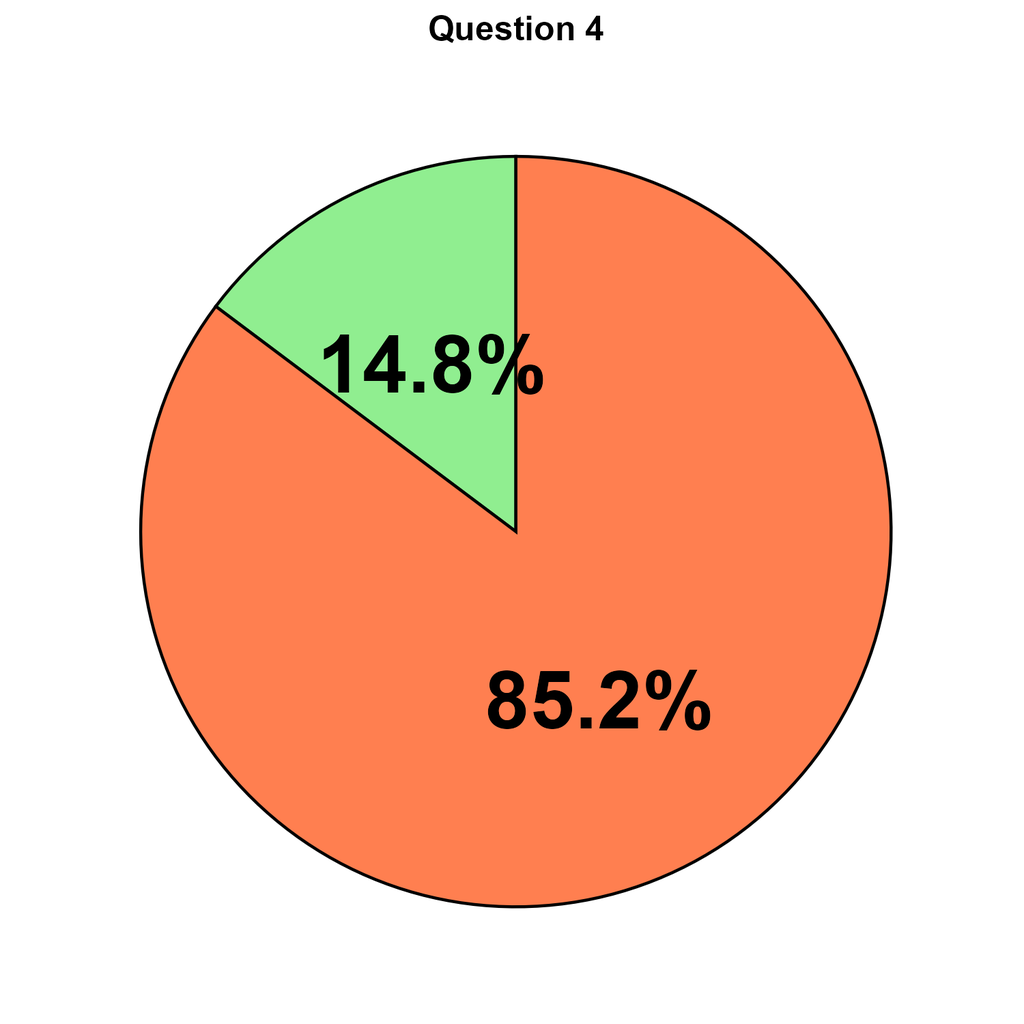

Question 5 (True): South Asians develop coronary artery disease up to 10 years earlier than other racial/ethnic groups, on average.

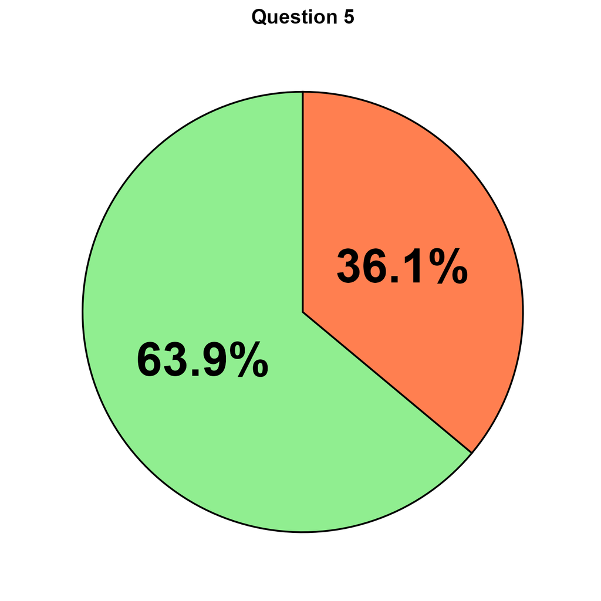

Question 6 (False): South Asians often have higher levels of HDL cholesterol than other groups.

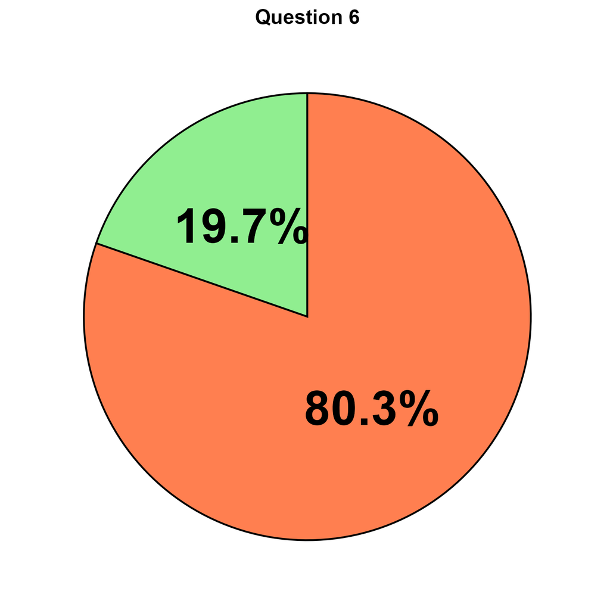

Question 7 (True): A cardiovascular disease risk model helps doctors predict heart disease risk based on health and lifestyle factors.

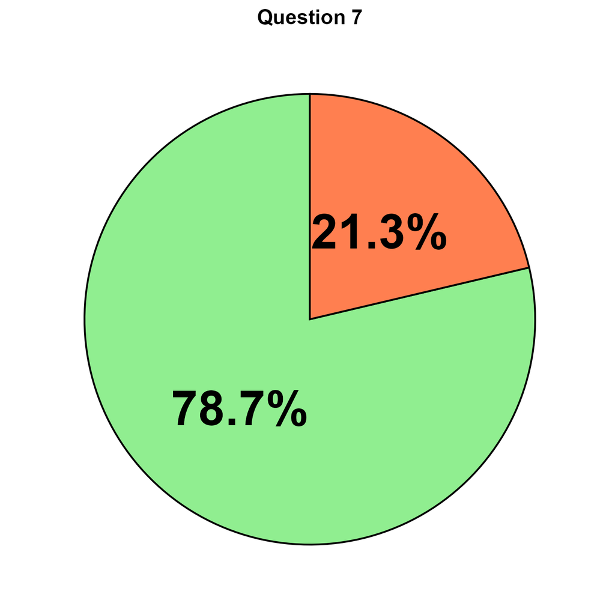

Question 8 (False): The research models that U.S. doctors use to predict heart disease risk for patients are the same for all individuals.

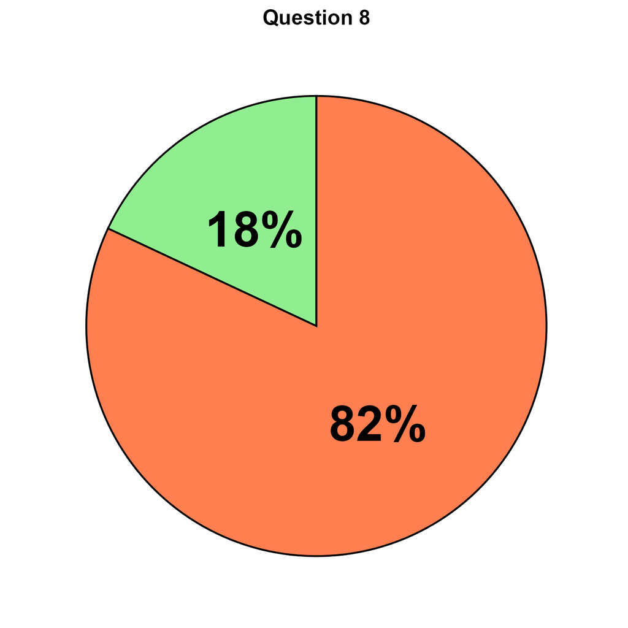

Question 9 (False): The research models that U.S. doctors use to predict heart disease risk are updated annually.

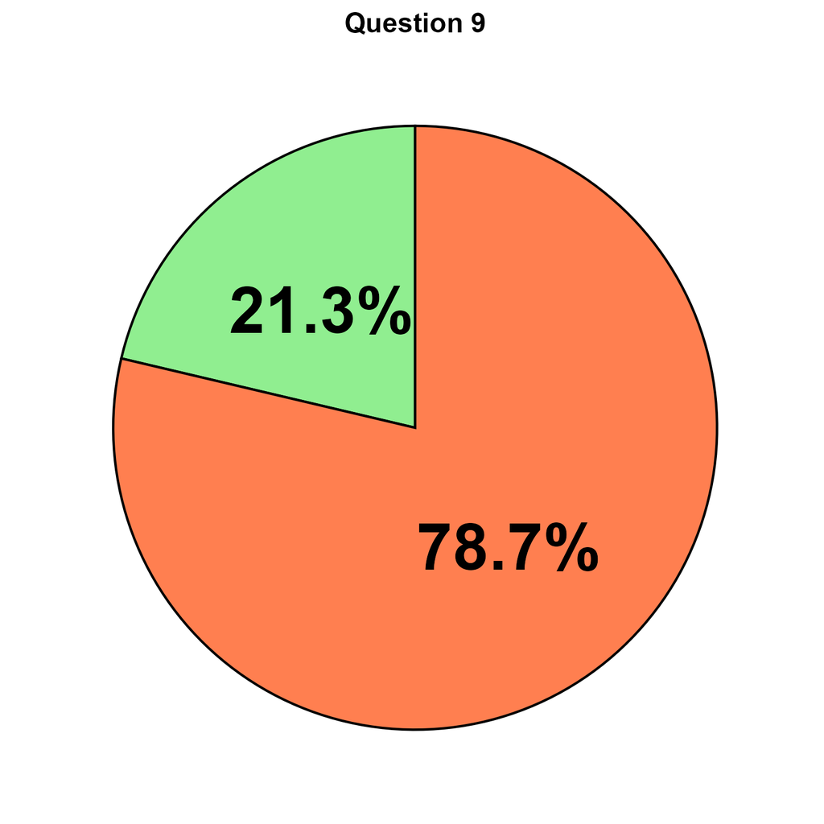

Question 10 (False): U.S. heart disease risk models are based primarily on data from various racial/ethnic groups.

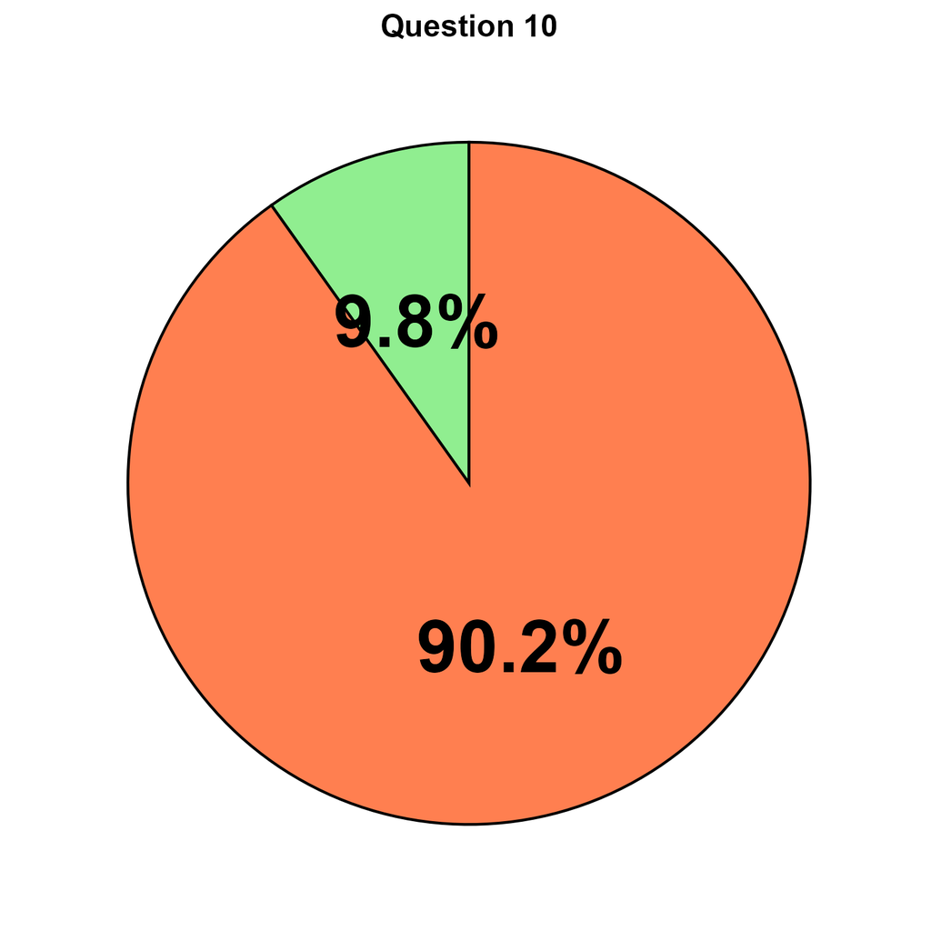

Question 11 (True): South Asians tend to have higher levels of abdominal fat compared to other groups.

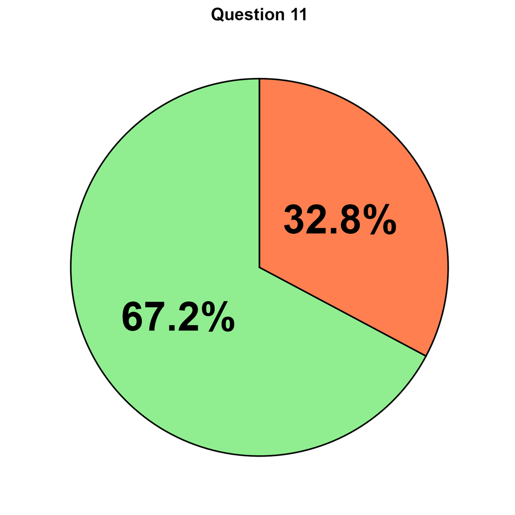

Question 12 (True): Shortness of breath is a common symptom of heart disease in South Asians.

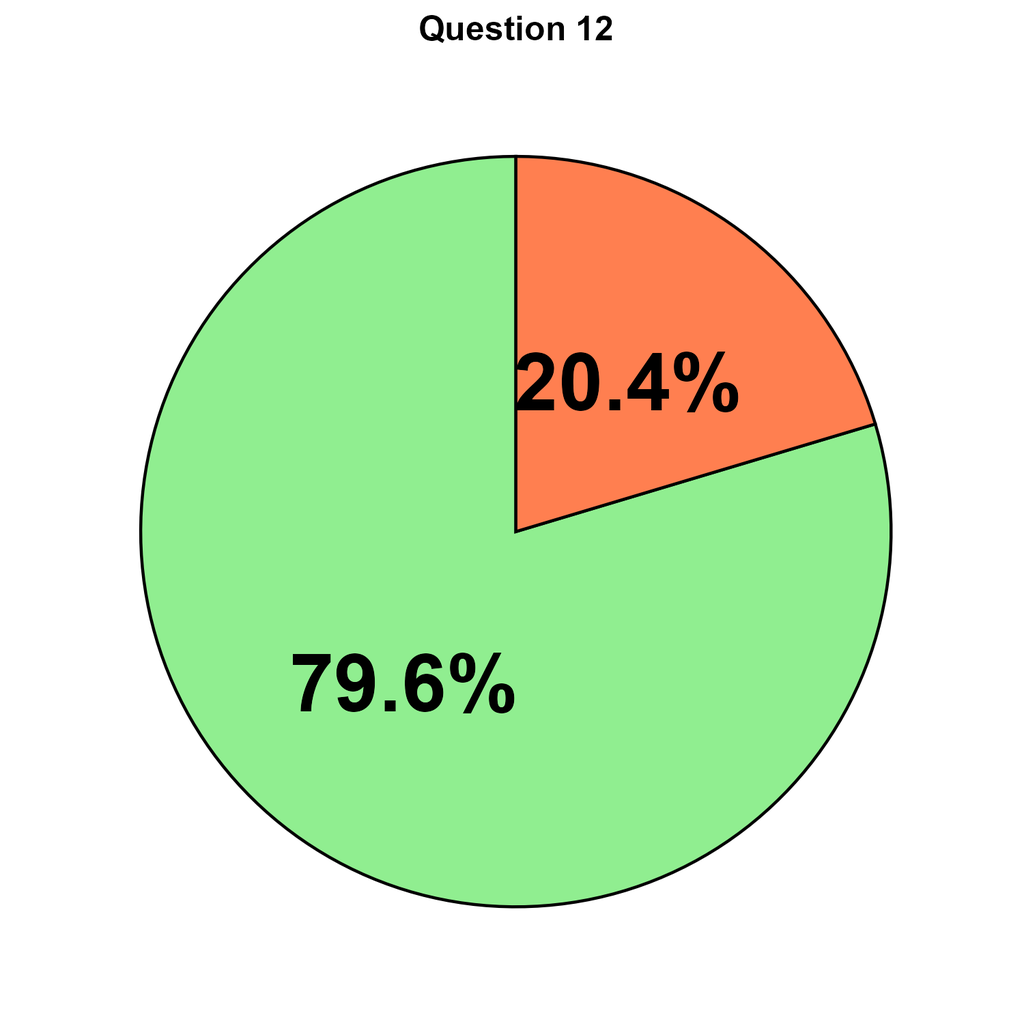

Data source: SACVD (2024-2025)

```r
# Create a data frame with text descriptions and image file paths
df <- data.frame(
  Question = c(
    "Question 1 (False): Fat is stored predominantly in the liver for all individuals.",
    "Question 2 (True): South Asians account for 60 percent of the world's heart disease patients.",
    "Question 3 (True): Lipoprotein(a) is a type of fat in the body that's a genetically determined risk factor for heart disease and stroke.",
    "Question 4 (False): South Asians have higher levels of fat that increase heart disease risk compared to Caucasians, but have lower levels of this fat compared to other groups.",
    "Question 5 (True): South Asians develop coronary artery disease up to 10 years earlier than other racial/ethnic groups, on average.",
    "Question 6 (False): South Asians often have higher levels of HDL cholesterol than other groups.",
    "Question 7 (True): A cardiovascular disease risk model helps doctors predict heart disease risk based on health and lifestyle factors.",
    "Question 8 (False): The research models that U.S. doctors use to predict heart disease risk for patients are the same for all individuals.",
    "Question 9 (False): The research models that U.S. doctors use to predict heart disease risk are updated annually.",
    "Question 10 (False): U.S. heart disease risk models are based primarily on data from various racial/ethnic groups.",
    "Question 11 (True): South Asians tend to have higher levels of abdominal fat compared to other groups.",
    "Question 12 (True): Shortness of breath is a common symptom of heart disease in South Asians."
  ),
  Image = c(
    "C:/Users/RMRAVEE/Desktop/Honors Thesis Data/pie_chart_TF1accuracy.png",
    "C:/Users/RMRAVEE/Desktop/Honors Thesis Data/pie_chart_TF2accuracy.png",
    "C:/Users/RMRAVEE/Desktop/Honors Thesis Data/pie_chart_TF3accuracy.png",
    "C:/Users/RMRAVEE/Desktop/Honors Thesis Data/pie_chart_TF4accuracy.png",
    "C:/Users/RMRAVEE/Desktop/Honors Thesis Data/pie_chart_TF5accuracy.png",
    "C:/Users/RMRAVEE/Desktop/Honors Thesis Data/pie_chart_TF6accuracy.png",
    "C:/Users/RMRAVEE/Desktop/Honors Thesis Data/pie_chart_TF7accuracy.png",
    "C:/Users/RMRAVEE/Desktop/Honors Thesis Data/pie_chart_TF8accuracy.png",
    "C:/Users/RMRAVEE/Desktop/Honors Thesis Data/pie_chart_TF9accuracy.png",
    "C:/Users/RMRAVEE/Desktop/Honors Thesis Data/pie_chart_TF10accuracy.png",
    "C:/Users/RMRAVEE/Desktop/Honors Thesis Data/pie_chart_TF11accuracy.png",
    "C:/Users/RMRAVEE/Desktop/Honors Thesis Data/pie_chart_TF12accuracy.png"  # Make sure to save and add TF12
  )
)

# Create the gt table
gt_table_accuracy <- df %>%
  gt() %>%
  text_transform(
    locations = cells_body(columns = Image),
    fn = function(x) {
      local_image(filename = x, height = 100)  # Adjust height as needed
    }
  ) %>%
  tab_header(
    title = md("**Table 9. Accuracy for True or False Survey Questions**")
  ) %>%
  cols_label(
    Question = " ",
    Image = " "
  ) %>%
  tab_options(
    table.width = px(700),
    column_labels.hidden = TRUE
  )%>%
  tab_options(
    table.font.names = "Times New Roman"
  ) %>%
  tab_source_note(source_note = "Data source: SACVD (2024-2025)") %>%
  tab_options(source_notes.font.size = 12) %>%
  tab_options(
    table_body.border.bottom.width = 2,
    table_body.border.bottom.color = "grey"
)

# Display the table
gt_table_accuracy
```

```r
#Save the table
output_path <- "C:/Users/RMRAVEE/Desktop/Honors Thesis Data/accuracy_table.png"
gtsave(gt_table_accuracy, filename = output_path, vwidth = 8000, vheight = 6000)
```

```
file:///C:/Users/RMRAVEE/AppData/Local/Temp/RtmpS2SyD4/fileab8020bd67a1.html screenshot completed
```

## Creating Binary Accuracy Variables

The true or false accuracy variables were also encoded into binary variables to encode “Correct” as 1 and “Incorrect” as 0 into new variables called TFaccuracy#_num, to assist with further analysis.

```r
# List of specific variables to recode
accuracy_vars <- c("TF1accuracy", "TF2accuracy", "TF3accuracy", "TF4accuracy",
                   "TF5accuracy", "TF6accuracy", "TF7accuracy", "TF8accuracy",
                   "TF9accuracy", "TF10accuracy", "TF11accuracy", "TF12accuracy")

# Apply transformation: Create new variables TF#accuracy_num
sacvd <- sacvd %>%
  mutate(across(all_of(accuracy_vars), ~ ifelse(. == "Correct", 1, 0),
                .names = "{.col}_num"))
```

The next step was also creating dummy variables for the demographic predictors to assign categories to 0 and 1.

```r
sacvd$Sex <- factor(sacvd$Sex, levels = c("Male", "Female"))  # Male is reference
sacvd$HighestDegreeElse <- factor(sacvd$HighestDegreeElse, levels = c("Graduate Degree", "Bachelors Degree or Lower"))
sacvd$Employment2Else <- factor(sacvd$Employment2Else, levels = c("Employed for wages", "Other"))
sacvd$Diet2Else <- factor(sacvd$Diet2Else, levels = c("No specific dietary restrictions", "Other"))
sacvd$Religion3Else <- factor(sacvd$Religion3Else, levels = c("Hinduism", "Other"))
sacvd$Immigration.Status2Else <- factor(sacvd$Immigration.Status2Else, levels = c("Yes, I immigrated to the U.S.", "No and Other"))
sacvd$Cardiometabolic.DiseaseElse <- factor(sacvd$Cardiometabolic.DiseaseElse, levels = c("Yes", "No"))
```

## Demographic Tables

Demographic tables were then created to summarize the overall distribution of responses in the data set.

*Categorical Data (Demographic Predictors)*

```r
#Creating a demographic table to see the distribution of all results
# Define new variable titles
variable_titles <- c(
  "Sex" = "Sex",
  "HighestDegree2" = "Highest Degree Earned",
  "Employment2" = "Employment Status",
  "Religion3" = "Religion",
  "Diet2" = "Diet",
  "Immigration.Status2" = "Immigration Status",
  "Cardiometabolic.Disease" = "Presence of Cardiometabolic Disease",
  "South.Asian.Country.of.Origin" = "South Asian Country of Origin",
  "State" = "United States State of Origin"
)

# Function to create the demographic table with proper formatting
create_demographic_table <- function(data, vars, title_map) {
  demographic_table <- bind_rows(
    lapply(vars, function(var) {
      data %>%
        filter(!is.na(.data[[var]])) %>%  # Remove NAs
        count(.data[[var]]) %>%
        mutate(Variable = title_map[var],  # Apply new names
               Percentage = round((n / sum(n)) * 100, 1)) %>%
        rename(Category = .data[[var]], Count = n)
    })
  ) %>%
    select(Variable, Category, Count, Percentage) %>%
    group_by(Variable) %>%
    mutate(Variable = ifelse(row_number() == 1, Variable, "")) %>%  # Show variable name only once per section
    ungroup()

  return(demographic_table)
}

# List of variable names (use existing column names in sacvd)
variable_list <- names(variable_titles)

# Generate demographic table with formatted variable names
demographic_summary <- create_demographic_table(sacvd, variable_list, variable_titles)

demographic_table <- demographic_summary %>%
  gt() %>%
      tab_header(
    title = 'Demographic Distribution of Data for Categorical Variables',
  )%>%
  tab_options(
    heading.title.font.size = px(40),  # Increase title font size
    heading.title.font.weight = "bold"  # Keep it bold
  ) %>%
    cols_align(
    align = "center",
    columns = where(is.numeric)  # Centers only numeric columns (Count & Percentage)
  ) %>%
  cols_align(
    align = "left",
    columns = c(Variable, Category)  # Left-aligns text columns
  ) %>%
    cols_width(
    Variable ~ px(200),   # Adjust Variable column width
    Category ~ px(900),   # Make Category column wider
    Count ~ px(100),      # Keep Count column compact
    Percentage ~ px(120)  # Keep Percentage readable
  ) %>%
    tab_style(
    style = list(
      cell_fill(color = "lightblue"),  # Set background color
      cell_text(weight = "bold", color = "black")  # Make text bold
    ),
    locations = cells_body(
      columns = Variable,  # Apply to Variable column
      rows = Variable != ""  # Only color rows where the Variable is not empty
    )
  ) %>%
  tab_source_note(source_note = "Data source: SACVD (2024-2025)") %>%
  tab_options(source_notes.font.size = 12) %>%
  tab_options(
    table_body.border.bottom.width = 2,
    table_body.border.bottom.color = "grey",
    table.width = px(800)
) %>%
  tab_options(
    table.font.names = "Times New Roman"  # Set font to Times New Roman
  )

gtsave(demographic_table, "C:/Users/RMRAVEE/Desktop/Honors Thesis Data/demographics_table.png", vwidth = 3000, vheight = 900)
```

```
file:///C:/Users/RMRAVEE/AppData/Local/Temp/RtmpS2SyD4/fileab80126e687c.html screenshot completed
```

*Quantitative Data (‘SS’ Predictors and Age)*

```r
# Create a summary table for quantitative variables
summary_table <- sacvd %>%
  summarise(
    Age_Mean = round(mean(Age, na.rm=TRUE), 1),
    Age_Median = round(median(Age, na.rm=TRUE), 1),
    Age_SD = round(sd(Age, na.rm=TRUE), 1),
    Age_Min = min(Age, na.rm=TRUE),
    Age_Max = max(Age, na.rm=TRUE),

    SummaryScore_Mean = round(mean(SummaryScore, na.rm=TRUE), 1),
    SummaryScore_Median = round(median(SummaryScore, na.rm=TRUE), 1),
    SummaryScore_SD = round(sd(SummaryScore, na.rm=TRUE), 1),
    SummaryScore_Min = min(SummaryScore, na.rm=TRUE),
    SummaryScore_Max = max(SummaryScore, na.rm=TRUE),

    SS1_Mean = round(mean(SS1_plus1, na.rm=TRUE), 1),
    SS1_Median = round(median(SS1_plus1, na.rm=TRUE), 1),
    SS1_SD = round(sd(SS1_plus1, na.rm=TRUE), 1),
    SS1_Min = min(SS1_plus1, na.rm=TRUE),
    SS1_Max = max(SS1_plus1, na.rm=TRUE),

    SS2_Mean = round(mean(SS2_plus1, na.rm=TRUE), 1),
    SS2_Median = round(median(SS2_plus1, na.rm=TRUE), 1),
    SS2_SD = round(sd(SS2_plus1, na.rm=TRUE), 1),
    SS2_Min = min(SS2_plus1, na.rm=TRUE),
    SS2_Max = max(SS2_plus1, na.rm=TRUE),

    SS3_Mean = round(mean(SS3_plus1, na.rm=TRUE), 1),
    SS3_Median = round(median(SS3_plus1, na.rm=TRUE), 1),
    SS3_SD = round(sd(SS3_plus1, na.rm=TRUE), 1),
    SS3_Min = min(SS3_plus1, na.rm=TRUE),
    SS3_Max = max(SS3_plus1, na.rm=TRUE),

    SS4_Mean = round(mean(SS4_plus1, na.rm=TRUE), 1),
    SS4_Median = round(median(SS4_plus1, na.rm=TRUE), 1),
    SS4_SD = round(sd(SS4_plus1, na.rm=TRUE), 1),
    SS4_Min = min(SS4_plus1, na.rm=TRUE),
    SS4_Max = max(SS4_plus1, na.rm=TRUE),

    SS5_Mean = round(mean(SS5_plus1, na.rm=TRUE), 1),
    SS5_Median = round(median(SS5_plus1, na.rm=TRUE), 1),
    SS5_SD = round(sd(SS5_plus1, na.rm=TRUE), 1),
    SS5_Min = min(SS5_plus1, na.rm=TRUE),
    SS5_Max = max(SS5_plus1, na.rm=TRUE),

    SS6_Mean = round(mean(SS6_plus1, na.rm=TRUE), 1),
    SS6_Median = round(median(SS6_plus1, na.rm=TRUE), 1),
    SS6_SD = round(sd(SS6_plus1, na.rm=TRUE), 1),
    SS6_Min = min(SS6_plus1, na.rm=TRUE),
    SS6_Max = max(SS6_plus1, na.rm=TRUE),

    SS7_Mean = round(mean(SS7_plus1, na.rm=TRUE), 1),
    SS7_Median = round(median(SS7_plus1, na.rm=TRUE), 1),
    SS7_SD = round(sd(SS7_plus1, na.rm=TRUE), 1),
    SS7_Min = min(SS7_plus1, na.rm=TRUE),
    SS7_Max = max(SS7_plus1, na.rm=TRUE),

    SS8_Mean = round(mean(SS8_plus1, na.rm=TRUE), 1),
    SS8_Median = round(median(SS8_plus1, na.rm=TRUE), 1),
    SS8_SD = round(sd(SS8_plus1, na.rm=TRUE), 1),
    SS8_Min = min(SS8_plus1, na.rm=TRUE),
    SS8_Max = max(SS8_plus1, na.rm=TRUE),

    SS9_Mean = round(mean(SS9_plus1, na.rm=TRUE), 1),
    SS9_Median = round(median(SS9_plus1, na.rm=TRUE), 1),
    SS9_SD = round(sd(SS9_plus1, na.rm=TRUE), 1),
    SS9_Min = min(SS9_plus1, na.rm=TRUE),
    SS9_Max = max(SS9_plus1, na.rm=TRUE)
  ) %>%
  pivot_longer(cols = everything(), names_to = "Statistic", values_to = "Value") %>%
  separate(Statistic, into = c("Variable", "Stat"), sep = "_") %>%
  pivot_wider(names_from = Stat, values_from = Value)

summary_table <- summary_table %>%
  mutate(Variable = case_when(
    Variable == "SummaryScore" ~ "Summary Score",
    Variable == "SS1" ~ "Connection to South Asian Identity",
    Variable == "SS2" ~ "Religosity",
    Variable == "SS3" ~ "Regular Consumption of South Asian Typical Diet",
    Variable == "SS4" ~ "Regular Thought About Heart Health",
    Variable == "SS5" ~ "Trust in Healthcare Providers",
    Variable == "SS6" ~ "Knowledge of MASALA",
    Variable == "SS7" ~ "Knowledge of Policy Changes",
    Variable == "SS8" ~ "Regular Social Media Use",
    Variable == "SS9" ~ "Confidence in Survey Accuracy",
    TRUE ~ Variable  # Keeps any other variables unchanged
  ))

# Print the summary table
summary_table_quant <- summary_table %>%
  gt() %>%
  tab_header(title = 'Descriptive Statistics for Quantitative Variables') %>%
  cols_label(Variable = "Variable Name", Mean = "Mean", Median = "Median", SD = "Standard Deviation", Min = "Min", Max = "Max") %>%
  cols_align(align = "left") %>%
  tab_source_note(source_note = "Data source: SACVD (2024-2025)") %>%
  tab_options(source_notes.font.size = 12) %>%
  tab_options(
    table_body.border.bottom.width = 2,
    table_body.border.bottom.color = "grey",
    table.width = px(800)
)%>%
  fmt_number(columns = where(is.numeric), decimals = 0) %>%
  tab_options(
    table.font.names = "Times New Roman"  # Set font to Times New Roman
  )

gtsave(summary_table_quant, "C:/Users/RMRAVEE/Desktop/Honors Thesis Data/demographics_table_quant.png", vwidth = 4000, vheight = 200)
```

```
file:///C:/Users/RMRAVEE/AppData/Local/Temp/RtmpS2SyD4/fileab8012f36ee9.html screenshot completed
```

## Logistic Regression - Testing Assumptions to Run Tests Between Variables

*1) Checking for Multicollinearity*

The first assumption to test was assessing if multicollinearity was present among any of the predictor variables. If a VIF value was greater than 5, this indicated a potential assumption violation. The ‘SS’ variables and Age were tested first and separately from the other demographic predictors to the respective nature of each of the variables (numerical variables versus binary variables).

*SS Variables and Age*

```r
# List of TF accuracy numeric variables
tf_accuracy_vars <- c("TF1accuracy_num", "TF2accuracy_num", "TF3accuracy_num",
                      "TF4accuracy_num", "TF5accuracy_num", "TF6accuracy_num",
                      "TF7accuracy_num", "TF8accuracy_num", "TF9accuracy_num",
                      "TF10accuracy_num", "TF11accuracy_num", "TF12accuracy_num")

# Run logistic regression and calculate VIF for each TF#accuracy_num variable
for (tf_var in tf_accuracy_vars) {
  model <- glm(as.formula(paste(tf_var, "~ Age + SS1_plus1 + SS2_plus1 + SS3_plus1 + SS4_plus1 + SS5_plus1 + SS6_plus1 + SS7_plus1 + SS8_plus1 + SS9_plus1")),
               data = sacvd, family = binomial)

  vif_values <- vif(model)

  print(paste("VIF for model:", tf_var))
  print(vif_values)
  cat("\n---------------------------------\n")
}
```

```
[1] "VIF for model: TF1accuracy_num"
      Age SS1_plus1 SS2_plus1 SS3_plus1 SS4_plus1 SS5_plus1 SS6_plus1 SS7_plus1
 1.277448  2.266643  2.292410  2.175136  1.399816  1.667009  2.304376  1.835945
SS8_plus1 SS9_plus1
 1.343481  1.395938

---------------------------------
[1] "VIF for model: TF2accuracy_num"
      Age SS1_plus1 SS2_plus1 SS3_plus1 SS4_plus1 SS5_plus1 SS6_plus1 SS7_plus1
 1.420378  2.286466  2.948656  2.251086  1.454906  1.483338  1.719721  1.389763
SS8_plus1 SS9_plus1
 1.273467  1.310042

---------------------------------
[1] "VIF for model: TF3accuracy_num"
      Age SS1_plus1 SS2_plus1 SS3_plus1 SS4_plus1 SS5_plus1 SS6_plus1 SS7_plus1
 1.987237  2.600799  3.157066  2.977430  1.394221  2.083086  1.700389  1.560669
SS8_plus1 SS9_plus1
 1.636231  1.268707

---------------------------------
[1] "VIF for model: TF4accuracy_num"
      Age SS1_plus1 SS2_plus1 SS3_plus1 SS4_plus1 SS5_plus1 SS6_plus1 SS7_plus1
 1.528596  2.497347  2.049039  3.799679  2.925943  4.488135  2.883796  2.131665
SS8_plus1 SS9_plus1
 2.271129  1.602898

---------------------------------
[1] "VIF for model: TF5accuracy_num"
      Age SS1_plus1 SS2_plus1 SS3_plus1 SS4_plus1 SS5_plus1 SS6_plus1 SS7_plus1
 1.420141  2.038274  2.571783  2.025694  1.422588  1.489408  1.915656  1.522493
SS8_plus1 SS9_plus1
 1.413337  1.479362

---------------------------------
[1] "VIF for model: TF6accuracy_num"
      Age SS1_plus1 SS2_plus1 SS3_plus1 SS4_plus1 SS5_plus1 SS6_plus1 SS7_plus1
 1.318579  1.911131  2.093759  2.756288  1.665959  1.653218  2.047468  1.391490
SS8_plus1 SS9_plus1
 1.396308  1.380718
```

[output cut: 29 more lines]

```
---------------------------------
[1] "VIF for model: TF11accuracy_num"
      Age SS1_plus1 SS2_plus1 SS3_plus1 SS4_plus1 SS5_plus1 SS6_plus1 SS7_plus1
 1.422468  3.558670  2.812714  3.041307  1.722959  1.533693  4.091343  2.598731
SS8_plus1 SS9_plus1
 1.172348  1.453035

---------------------------------
[1] "VIF for model: TF12accuracy_num"
      Age SS1_plus1 SS2_plus1 SS3_plus1 SS4_plus1 SS5_plus1 SS6_plus1 SS7_plus1
 1.377022  3.491239  3.705504  4.498212  1.503103  1.749030  2.436593  2.238619
SS8_plus1 SS9_plus1
 1.598289  1.313204

---------------------------------
```

The only VIF variable greater than 5 was between SS2 predicting TF7 (VIF = 7.378184). The relationship between SS2 and TF7 was later found to be insignificant.

*Demographic Predictors*

```r
# List of TF accuracy numeric variables
tf_accuracy_vars <- c("TF1accuracy_num", "TF2accuracy_num", "TF3accuracy_num",
                      "TF4accuracy_num", "TF5accuracy_num", "TF6accuracy_num",
                      "TF7accuracy_num", "TF8accuracy_num", "TF9accuracy_num",
                      "TF10accuracy_num", "TF11accuracy_num", "TF12accuracy_num")

# Run logistic regression and calculate VIF for each TF#accuracy_num variable
for (tf_var in tf_accuracy_vars) {
  model <- glm(as.formula(paste(tf_var, "~ Sex + HighestDegreeElse + Employment2Else + Diet2Else + Religion3Else + Immigration.Status2Else + Cardiometabolic.DiseaseElse")),
               data = sacvd, family = binomial)

  vif_values <- vif(model)

  print(paste("VIF for model:", tf_var))
  print(vif_values)
  cat("\n---------------------------------\n")
}
```

```
[1] "VIF for model: TF1accuracy_num"
                        Sex           HighestDegreeElse
                   1.287968                    1.760609
            Employment2Else                   Diet2Else
                   2.563787                    1.512294
              Religion3Else     Immigration.Status2Else
                   1.520960                    3.050984
Cardiometabolic.DiseaseElse
                   1.000001

---------------------------------
[1] "VIF for model: TF2accuracy_num"
                        Sex           HighestDegreeElse
                   2.051161                    2.585381
            Employment2Else                   Diet2Else
                   3.354332                    1.588708
              Religion3Else     Immigration.Status2Else
                   1.409510                    3.106758
Cardiometabolic.DiseaseElse
                   3.089857

---------------------------------
```

```
[1] "VIF for model: TF3accuracy_num"
                        Sex           HighestDegreeElse
               1.941211e+07                1.387369e+08
            Employment2Else                   Diet2Else
               1.585721e+00                1.525675e+00
              Religion3Else     Immigration.Status2Else
               1.016234e+00                1.193248e+08
Cardiometabolic.DiseaseElse
               1.608660e+00

---------------------------------
```

```
[1] "VIF for model: TF4accuracy_num"
                        Sex           HighestDegreeElse
                   3.022230                    1.963770
            Employment2Else                   Diet2Else
                   2.993309                    5.146029
              Religion3Else     Immigration.Status2Else
                   2.525841                    2.892222
Cardiometabolic.DiseaseElse
                   2.167787

---------------------------------
[1] "VIF for model: TF5accuracy_num"
                        Sex           HighestDegreeElse
                   1.308114                    2.164083
            Employment2Else                   Diet2Else
                   2.018998                    1.305335
              Religion3Else     Immigration.Status2Else
                   1.361170                    2.845091
Cardiometabolic.DiseaseElse
                   1.000001

---------------------------------
```

```
[1] "VIF for model: TF6accuracy_num"
                        Sex           HighestDegreeElse
               4.721321e+06                9.232562e+06
            Employment2Else                   Diet2Else
               4.025548e+07                9.232561e+06
              Religion3Else     Immigration.Status2Else
               1.399880e+00                3.412017e+07
Cardiometabolic.DiseaseElse
               3.495809e+07

---------------------------------
[1] "VIF for model: TF7accuracy_num"
                        Sex           HighestDegreeElse
               1.308224e+00                1.550562e+00
            Employment2Else                   Diet2Else
               1.018633e+07                1.128619e+00
              Religion3Else     Immigration.Status2Else
               1.231507e+00                1.018633e+07
Cardiometabolic.DiseaseElse
               1.665643e+00

---------------------------------
[1] "VIF for model: TF8accuracy_num"
                        Sex           HighestDegreeElse
               2.397555e+00                2.897244e+00
            Employment2Else                   Diet2Else
               6.870252e+06                2.297476e+00
              Religion3Else     Immigration.Status2Else
               1.669830e+00                1.783363e+00
Cardiometabolic.DiseaseElse
               6.870254e+06

---------------------------------
```

```
[1] "VIF for model: TF9accuracy_num"
                        Sex           HighestDegreeElse
                   2.254334                    2.000062
            Employment2Else                   Diet2Else
                   5.215581                   11.509345
              Religion3Else     Immigration.Status2Else
                   5.909822                    7.264333
Cardiometabolic.DiseaseElse
                   2.277333

---------------------------------
```

```
[1] "VIF for model: TF10accuracy_num"
                        Sex           HighestDegreeElse
                   1.184307                    2.737299
            Employment2Else                   Diet2Else
                   5.183938                    1.633226
              Religion3Else     Immigration.Status2Else
                   1.307524                    7.160807
Cardiometabolic.DiseaseElse
                   2.832201

---------------------------------
[1] "VIF for model: TF11accuracy_num"
                        Sex           HighestDegreeElse
                   1.913120                    2.554924
            Employment2Else                   Diet2Else
                   2.531361                    1.276840
              Religion3Else     Immigration.Status2Else
                   1.485527                    3.199104
Cardiometabolic.DiseaseElse
                   1.000001

---------------------------------
```

```
[1] "VIF for model: TF12accuracy_num"
                        Sex           HighestDegreeElse
               2.005836e+00                2.166391e+00
            Employment2Else                   Diet2Else
               1.319241e+07                1.618988e+00
              Religion3Else     Immigration.Status2Else
               9.260783e+06                1.657460e+07
Cardiometabolic.DiseaseElse
               1.273377e+00

---------------------------------
```

Many predictors co-vary and have VIF values greater than 5. None of the predictors were found to be significant predictors of accuracy on their own in later un-adjusted models, but did present the issue of co-variation with other ‘SS’ variables in fully adjusted models.

*2) Checking for Linearity of Log-Odds of ‘SS’ Variables and Age*

In logistic regression, the linearity assumption states that the log-odds of the outcome are linearly related to continuous predictors. If the relationship is non-linear, including a log-transformed term can capture that non-linearity. This is indicated when the p-value is less than 0.05 for the log-odds predictor. The demographic predictor variables, which were labeled as binary, were excluded from the linearity assessment as the linearity assumption applies to continuous variables. The binary, demographic variables inherently meet this assumption and do not require transformation or testing for linearity in the logit.

First we ran test the un-adjusted models, which just include each singular ‘SS’ Predictor variable and Age. Several relationships that were later found to be significant did demonstrate significance in both the log model and the standard variable, so these relationships were noted for consideration in further analysis.

```r
# List of TF accuracy numeric variables
tf_accuracy_vars <- paste0("TF", 1:12, "accuracy_num")

# List of SS predictors
ss_predictors <- paste0("SS", 1:9, "_plus1")

# Create an empty list to store significant results
individual_sig_results <- list()

# Loop through each TF accuracy variable
for (tf_var in tf_accuracy_vars) {

  # Loop through each SS predictor
  for (ss_var in ss_predictors) {

    # Model with SS predictor + Age
    glm_model_ss <- glm(as.formula(paste(tf_var, "~", ss_var, "+ Age")),
                        data = sacvd,
                        family = binomial)

    # Extract summary and significance
    model_summary_ss <- summary(glm_model_ss)
    coef_table_ss <- model_summary_ss$coefficients
    sig_vars_ss <- coef_table_ss[, 4] < 0.05 & rownames(coef_table_ss) != "(Intercept)"  # Exclude Intercept

    if (any(sig_vars_ss)) {
      OR_table_ss <- exp(coef_table_ss[sig_vars_ss, 1])
      CI_lower_ss <- exp(coef_table_ss[sig_vars_ss, 1] - 1.96 * coef_table_ss[sig_vars_ss, 2])
      CI_upper_ss <- exp(coef_table_ss[sig_vars_ss, 1] + 1.96 * coef_table_ss[sig_vars_ss, 2])

      sig_results_ss <- data.frame(
        TF_Accuracy = tf_var,
        Variable = rownames(coef_table_ss)[sig_vars_ss],
        Coefficient = coef_table_ss[sig_vars_ss, 1],
        Odds_Ratio = OR_table_ss,
        CI_Lower = CI_lower_ss,
        CI_Upper = CI_upper_ss,
        P_Value = coef_table_ss[sig_vars_ss, 4]
      )

      individual_sig_results[[paste(tf_var, ss_var, "raw_with_Age", sep = "_")]] <- sig_results_ss
    }

    # Model with log-transformed SS predictor + Age
    glm_model_log <- glm(as.formula(paste(tf_var, "~ log(", ss_var, ") + Age")),
                         data = sacvd,
                         family = binomial)

    # Extract summary and significance
    model_summary_log <- summary(glm_model_log)
    coef_table_log <- model_summary_log$coefficients
    sig_vars_log <- coef_table_log[, 4] < 0.05 & rownames(coef_table_log) != "(Intercept)"  # Exclude Intercept

    if (any(sig_vars_log)) {
      OR_table_log <- exp(coef_table_log[sig_vars_log, 1])
      CI_lower_log <- exp(coef_table_log[sig_vars_log, 1] - 1.96 * coef_table_log[sig_vars_log, 2])
      CI_upper_log <- exp(coef_table_log[sig_vars_log, 1] + 1.96 * coef_table_log[sig_vars_log, 2])

      sig_results_log <- data.frame(
        TF_Accuracy = tf_var,
        Variable = rownames(coef_table_log)[sig_vars_log],
        Coefficient = coef_table_log[sig_vars_log, 1],
        Odds_Ratio = OR_table_log,
        CI_Lower = CI_lower_log,
        CI_Upper = CI_upper_log,
        P_Value = coef_table_log[sig_vars_log, 4]
      )

      individual_sig_results[[paste(tf_var, ss_var, "log_with_Age", sep = "_")]] <- sig_results_log
    }
  }
}

# Combine all significant results into a single dataframe
individual_significant_results_df <- do.call(rbind, individual_sig_results)

# Clean TF_Accuracy column to show "Question #" instead of "TF#accuracy_num"
individual_significant_results_df$TF_Accuracy <- gsub("TF([0-9]+)accuracy_num", "Question \\1", individual_significant_results_df$TF_Accuracy)

# Reorder columns to have Predictor first, then Question
individual_significant_results_df <- individual_significant_results_df[, c("Variable", "TF_Accuracy", "Coefficient", "Odds_Ratio", "CI_Lower", "CI_Upper", "P_Value")]

# Create the gt table with updated order and labeling
gt_table_individual <- individual_significant_results_df %>%
  gt() %>%
  tab_header(
    title = 'Linearity Assumption Test: Unadjusted Model'
  ) %>%
  cols_label(
    Variable = "Predictor (SS or Age)",
    TF_Accuracy = "True/False Question",
    Coefficient = "Coefficient",
    Odds_Ratio = "Odds Ratio",
    CI_Lower = "95% CI (Lower)",
    CI_Upper = "95% CI (Upper)",
    P_Value = "P-Value"
  ) %>%
  cols_align(
    align = "center",
    columns = where(is.numeric)
  ) %>%
  fmt_number(columns = where(is.numeric), decimals = 3) %>%
  tab_source_note(source_note = "Data source: SACVD (2024-2025)") %>%
  tab_options(source_notes.font.size = 9) %>%
  tab_options(
    table_body.border.bottom.width = 2,
    table_body.border.bottom.color = "grey"
  ) %>%
  tab_options(
    table.font.names = "Times New Roman"
  )

# Save the table as an image
gtsave(gt_table_individual, "C:/Users/RMRAVEE/Desktop/Honors Thesis Data/gt_table_individual.png", vwidth = 4000, vheight = 200)
```

```
file:///C:/Users/RMRAVEE/AppData/Local/Temp/RtmpS2SyD4/fileab8070fa2c44.html screenshot completed
```

Next, we ran the same test but as a fully-adjusted model which includes all the ‘SS’ Predictor variables and Age in one model. Only the relationship between SS6 and TF1 was found to violate the assumption, which was found to later be an insignificant relationship regardless.

```r
# List of TF accuracy numeric variables
tf_accuracy_vars <- paste0("TF", 1:12, "accuracy_num")

# Create an empty list to store significant results
significant_results <- list()

# Loop through each TF accuracy variable
for (tf_var in tf_accuracy_vars) {

  # Run logistic regression model
glm_model <- glm(as.formula(paste(tf_var, "~",
                                  paste0("SS", 1:9, "_plus1 + log(SS", 1:9, "_plus1)", collapse = " + "),
                                  " + Age")),
                 data = sacvd,
                 family = binomial)

  # Extract model summary
  model_summary <- summary(glm_model)

  # Extract coefficients, standard errors, and p-values
  coef_table <- model_summary$coefficients
  sig_vars <- coef_table[, 4] < 0.05  # Identify significant variables (p < 0.05)

  if (any(sig_vars)) {  # If there are significant variables

    OR_table <- exp(coef_table[sig_vars, 1])  # Convert to odds ratios
    CI_lower <- exp(coef_table[sig_vars, 1] - 1.96 * coef_table[sig_vars, 2])  # 95% CI Lower
    CI_upper <- exp(coef_table[sig_vars, 1] + 1.96 * coef_table[sig_vars, 2])  # 95% CI Upper

    # Create a results dataframe
    sig_results <- data.frame(
      TF_Accuracy = tf_var,
      Variable = rownames(coef_table)[sig_vars],
      Coefficient = coef_table[sig_vars, 1],  # Include Coefficient
      Odds_Ratio = OR_table,
      CI_Lower = CI_lower,
      CI_Upper = CI_upper,
      P_Value = coef_table[sig_vars, 4]
    )

    # Store in list
    significant_results[[tf_var]] <- sig_results
  }
}

# Combine all results into a single dataframe
significant_results_df <- do.call(rbind, significant_results)

# Clean TF_Accuracy column: change "TF#accuracy_num" to "Question #"
significant_results_df$TF_Accuracy <- gsub("TF([0-9]+)accuracy_num", "Question \\1", significant_results_df$TF_Accuracy)

# Update SS6_plus1 to "Knowledge of MASALA (SS6)"
significant_results_df$Variable <- ifelse(significant_results_df$Variable == "SS6_plus1",
                                          "Knowledge of MASALA (SS6)",
                                          significant_results_df$Variable)

# Reorder columns: Predictor first, then Question
significant_results_df <- significant_results_df[, c("Variable", "TF_Accuracy", "Coefficient", "Odds_Ratio", "CI_Lower", "CI_Upper", "P_Value")]

# Create the gt table for only significant results with updated labels
gt_table_linearity <- significant_results_df %>%
  gt() %>%
  tab_header(
    title = 'Linearity Assumption Test: Fully Adjusted Model'
  ) %>%
  cols_label(
    Variable = "Sliding Scale Predictor",
    TF_Accuracy = "Question #",
    Coefficient = "Coefficient",
    Odds_Ratio = "Odds Ratio",
    CI_Lower = "95% CI (Lower)",
    CI_Upper = "95% CI (Upper)",
    P_Value = "P-Value"
  ) %>%
  cols_align(
    align = "center",
    columns = where(is.numeric)
  ) %>%
  fmt_number(columns = where(is.numeric), decimals = 3) %>%
  tab_source_note(source_note = "Data source: SACVD (2024-2025)") %>%
  tab_options(source_notes.font.size = 9) %>%
  tab_options(
    table_body.border.bottom.width = 2,
    table_body.border.bottom.color = "grey"
  ) %>%
  tab_options(
    table.font.names = "Times New Roman"
  )

# Save the updated table as an image
gtsave(gt_table_linearity, "C:/Users/RMRAVEE/Desktop/Honors Thesis Data/gt_table_linearity.png", vwidth = 4000, vheight = 200)
```

```
file:///C:/Users/RMRAVEE/AppData/Local/Temp/RtmpS2SyD4/fileab8026e1ea4.html screenshot completed
```

*3) Checking for Outliers Using the Cook’s Test*

The final assumption tested was the Cook’s test to detect potential outliers. Cook’s distance was only assessed for numerical, continuous predictors as the binary, demographic variables inherently have minimal variability and are less prone to exert undue influence on model estimates.

Per common practice, the Cook’s test was only tested on the fully adjusted model with all ‘SS’ variable predictors and Age, as the Cook’s Distance is designed for multi-variable models where multiple predictors can create leverage or interaction effects that influence estimates.

```r
for (tf_var in tf_accuracy_vars) {
  # Build the full formula string correctly
  formula_str <- paste(tf_var, "~ Age + SS1_plus1 + SS2_plus1 + SS3_plus1 + SS4_plus1 + SS5_plus1 + SS6_plus1 + SS7_plus1 + SS8_plus1 + SS9_plus1")

  # Run logistic regression model
  glm_model <- glm(as.formula(formula_str), data = sacvd, family = binomial)

  # Calculate Cook’s Distance
  cooksd <- cooks.distance(glm_model)
  high_influence <- which(cooksd > 1)

  cat("\n----------------------------------------\n")
  print(paste("Cook’s Distance Test for:", tf_var))
  cat("----------------------------------------\n")
  print(summary(cooksd))

  if (length(high_influence) == 0) {
    print("No influential observations detected (Cook's D < 1 for all cases).")
  } else {
    print(paste("Observations with high influence:", toString(high_influence)))
  }
}
```

```
----------------------------------------
[1] "Cook’s Distance Test for: TF1accuracy_num"
----------------------------------------
    Min.  1st Qu.   Median     Mean  3rd Qu.     Max.
0.002226 0.008435 0.022829 0.037785 0.049701 0.252552
[1] "No influential observations detected (Cook's D < 1 for all cases)."

----------------------------------------
[1] "Cook’s Distance Test for: TF2accuracy_num"
----------------------------------------
     Min.   1st Qu.    Median      Mean   3rd Qu.      Max.
0.0000107 0.0044138 0.0168329 0.0414907 0.0518315 0.4363703
[1] "No influential observations detected (Cook's D < 1 for all cases)."

----------------------------------------
[1] "Cook’s Distance Test for: TF3accuracy_num"
----------------------------------------
     Min.   1st Qu.    Median      Mean   3rd Qu.      Max.
3.200e-07 6.498e-04 8.340e-03 3.248e-02 4.799e-02 1.849e-01
[1] "No influential observations detected (Cook's D < 1 for all cases)."

----------------------------------------
[1] "Cook’s Distance Test for: TF4accuracy_num"
----------------------------------------
     Min.   1st Qu.    Median      Mean   3rd Qu.      Max.
0.0000000 0.0000070 0.0002928 0.1281032 0.0299654 1.4801003
[1] "Observations with high influence: 22, 29"

----------------------------------------
[1] "Cook’s Distance Test for: TF5accuracy_num"
----------------------------------------
     Min.   1st Qu.    Median      Mean   3rd Qu.      Max.
0.0002597 0.0025257 0.0193845 0.0356693 0.0411300 0.2724776
[1] "No influential observations detected (Cook's D < 1 for all cases)."

----------------------------------------
[1] "Cook’s Distance Test for: TF6accuracy_num"
----------------------------------------
     Min.   1st Qu.    Median      Mean   3rd Qu.      Max.
0.0001408 0.0020581 0.0067493 0.0463818 0.0452234 0.6954705
```

[output cut: 28 more lines]

```
[1] "Observations with high influence: 30"

----------------------------------------
[1] "Cook’s Distance Test for: TF11accuracy_num"
----------------------------------------
     Min.   1st Qu.    Median      Mean   3rd Qu.      Max.
0.0000000 0.0000166 0.0027641 0.0450936 0.0506159 0.3417649
[1] "No influential observations detected (Cook's D < 1 for all cases)."

----------------------------------------
[1] "Cook’s Distance Test for: TF12accuracy_num"
----------------------------------------
     Min.   1st Qu.    Median      Mean   3rd Qu.      Max.
0.0000000 0.0000239 0.0013672 0.0683807 0.0570184 0.9487234
[1] "No influential observations detected (Cook's D < 1 for all cases)."
```

Based on the outcomes of the Cook’s tests, variables that indicated outliers were noted to be considered in future analysis (true or false questions 4 and 10).

## Logistic Regression and Chi-square/Fisher’s Tests Between Variables

*1) SS + Age Variables - Un-adjusted Results*

Logistic Regression of Each SS Variable with Each TF Question Individually

```r
# Initialize a list to store significant results
sig_logistic_results <- list()

# Outer loop: SS predictors plus Age
for (predictor in c(paste0("SS", 1:9, "_plus1"), "Age")) {

  # Inner loop: TF outcome variables
  for (tf_num in 1:12) {
    outcome <- paste0("TF", tf_num, "accuracy_num")

    # Run logistic regression
    formula <- as.formula(paste(outcome, "~", predictor))
    model <- glm(formula, data = sacvd, family = binomial)

    # Extract coefficient summary
    coef_summary <- summary(model)$coefficients

    # Check if predictor is in the model and significant
    if (predictor %in% rownames(coef_summary)) {
      estimate <- coef_summary[predictor, "Estimate"]
      p_value <- coef_summary[predictor, "Pr(>|z|)"]

      # Store only significant results
      if (p_value < 0.05) {
        odds_ratio <- exp(estimate)
        ci <- exp(confint(model)[predictor, ])

        sig_logistic_results[[length(sig_logistic_results) + 1]] <- data.frame(
          Predictor = predictor,
          TF_Accuracy = outcome,
          Coefficient = estimate,
          Odds_Ratio = odds_ratio,
          CI_Lower = ci[1],
          CI_Upper = ci[2],
          P_Value = p_value
        )
      }
    }
  }
}

# Combine all significant results
sig_results_df <- do.call(rbind, sig_logistic_results)

# Create GT table with Times New Roman font
sig_results_gt <- sig_results_df %>%
  gt() %>%
  tab_header(title = "Significant Logistic Regression Results (p < 0.05)") %>%
  cols_label(
    Predictor = "Predictor Variable",
    TF_Accuracy = "True or False Question",
    Coefficient = "Coefficient",
    Odds_Ratio = "Odds Ratio",
    CI_Lower = "95% CI (Lower)",
    CI_Upper = "95% CI (Upper)",
    P_Value = "P-Value"
  ) %>%
  fmt_number(columns = c(Coefficient, Odds_Ratio, CI_Lower, CI_Upper, P_Value), decimals = 3) %>%
  tab_source_note(source_note = "Data source: SACVD (2024-2025)") %>%
  tab_options(table.font.names = "Times New Roman")

sig_results_gt
```

Significant Logistic Regression Results (p < 0.05)

| Predictor Variable | True or False Question | Coefficient | Odds Ratio | 95% CI (Lower) | 95% CI (Upper) | P-Value |
| --- | --- | --- | --- | --- | --- | --- |
| SS2_plus1 | TF9accuracy_num | −0.550 | 0.577 | 0.361 | 0.877 | 0.013 |
| SS4_plus1 | TF4accuracy_num | −0.880 | 0.415 | 0.194 | 0.743 | 0.008 |
| SS5_plus1 | TF3accuracy_num | 0.641 | 1.898 | 1.200 | 3.196 | 0.009 |
| SS6_plus1 | TF7accuracy_num | 1.414 | 4.113 | 1.313 | 18.778 | 0.045 |
| SS6_plus1 | TF11accuracy_num | 1.245 | 3.474 | 1.315 | 13.114 | 0.042 |
| SS7_plus1 | TF3accuracy_num | 0.764 | 2.147 | 1.122 | 5.271 | 0.049 |
| SS8_plus1 | TF5accuracy_num | 0.408 | 1.503 | 1.102 | 2.111 | 0.013 |
| SS9_plus1 | TF3accuracy_num | 0.487 | 1.627 | 1.040 | 2.658 | 0.039 |

Data source: SACVD (2024-2025)

```r
#CREATE TABLE FOR THESIS
# Load your existing significant results table
sig_results <- data.frame(
  SS_Predictor = c("SS2_plus1", "SS4_plus1", "SS5_plus1", "SS6_plus1", "SS6_plus1", "SS7_plus1", "SS8_plus1", "SS9_plus1"),
  TF_Accuracy = c("TF9accuracy_num", "TF4accuracy_num", "TF3accuracy_num", "TF7accuracy_num", "TF11accuracy_num",
                  "TF3accuracy_num", "TF5accuracy_num", "TF3accuracy_num"),
  Coefficient = c(-0.550, -0.880, 0.641, 1.414, 1.245, 0.764, 0.408, 0.487),
  Odds_Ratio = c(0.577, 0.415, 1.898, 4.113, 3.474, 2.147, 1.503, 1.627),
  CI_Lower = c(0.361, 0.194, 1.200, 1.313, 1.315, 1.122, 1.102, 1.040),
  CI_Upper = c(0.877, 0.743, 3.196, 18.778, 13.114, 5.271, 2.111, 2.658),
  P_Value = c(0.013, 0.008, 0.009, 0.045, 0.042, 0.049, 0.013, 0.039)
)

# Create the mapping for SS variable names
ss_labels <- c(
  "SS2_plus1" = "Religiosity",
  "SS4_plus1" = "Regular Thought About Heart Health",
  "SS5_plus1" = "Trust in Healthcare Providers",
  "SS6_plus1" = "Knowledge of MASALA",
  "SS7_plus1" = "Knowledge of Policy Changes",
  "SS8_plus1" = "Regular Social Media Use",
  "SS9_plus1" = "Confidence in Survey Accuracy"
)

# Clean the TF labels to "Question #"
sig_results <- sig_results %>%
  mutate(
    SS_Predictor = ss_labels[SS_Predictor],
    TF_Accuracy = gsub("TF([0-9]+)accuracy_num", "Question \\1", TF_Accuracy)
  )

# Generate the gt table
unadjusted_logistic_regression <- sig_results %>%
  gt() %>%
  tab_header(title = "Logistic Regression Results (p < 0.05): Unadjusted Model") %>%
  cols_label(
    SS_Predictor = "Predictor Variable",
    TF_Accuracy = "True or False Question",
    Coefficient = "Coefficient",
    Odds_Ratio = "Odds Ratio",
    CI_Lower = "95% CI (Lower)",
    CI_Upper = "95% CI (Upper)",
    P_Value = "P-Value"
  ) %>%
  fmt_number(columns = c(Coefficient, Odds_Ratio, CI_Lower, CI_Upper, P_Value), decimals = 3) %>%
  tab_source_note(source_note = "Data source: SACVD (2024-2025)") %>%
  tab_options(table.font.names = "Times New Roman")

# Save the table as PNG for thesis
gtsave(unadjusted_logistic_regression,
       "C:/Users/RMRAVEE/Desktop/Honors Thesis Data/unadjusted_logistic_regression.png",
       vwidth = 5000, vheight = 200)

unadjusted_logistic_regression
```

Logistic Regression Results (p < 0.05): Unadjusted Model

| Predictor Variable | True or False Question | Coefficient | Odds Ratio | 95% CI (Lower) | 95% CI (Upper) | P-Value |
| --- | --- | --- | --- | --- | --- | --- |
| Religiosity | Question 9 | −0.550 | 0.577 | 0.361 | 0.877 | 0.013 |
| Regular Thought About Heart Health | Question 4 | −0.880 | 0.415 | 0.194 | 0.743 | 0.008 |
| Trust in Healthcare Providers | Question 3 | 0.641 | 1.898 | 1.200 | 3.196 | 0.009 |
| Knowledge of MASALA | Question 7 | 1.414 | 4.113 | 1.313 | 18.778 | 0.045 |
| Knowledge of MASALA | Question 11 | 1.245 | 3.474 | 1.315 | 13.114 | 0.042 |
| Knowledge of Policy Changes | Question 3 | 0.764 | 2.147 | 1.122 | 5.271 | 0.049 |
| Regular Social Media Use | Question 5 | 0.408 | 1.503 | 1.102 | 2.111 | 0.013 |
| Confidence in Survey Accuracy | Question 3 | 0.487 | 1.627 | 1.040 | 2.658 | 0.039 |

Data source: SACVD (2024-2025)

Various SS variables were found to be significant predictors of TF questions, which were then further analyzed through adjusted models. Relationships between SS and TF that were not found to be significant were not further analyzed in adjusted models.

Next, chi-square and Fisher’s test of each SSElse variable were tested to detect significant relationships between each true or false question. The assumptions for Chi-squared were run through a loop function that checked assumptions for all relationships between categorical variables and each True or False question. The code then automatically populated only results that were significant (p<0.05) into one table.

```r
# Limit predictors to SS1Else - SS9Else only
predictors <- paste0("SS", 1:9, "Else")

# Initialize results dataframe
sig_results <- data.frame(
  Predictor = character(),
  Outcome = character(),
  Test = character(),
  P_Value = numeric(),
  Odds_Ratio = numeric(),
  CI_Lower = numeric(),
  CI_Upper = numeric(),
  stringsAsFactors = FALSE
)

# Loop through SS predictors and TF1-12 outcomes
for (pred in predictors) {
  for (tf in paste0("TF", 1:12, "accuracy")) {
    # 2x2 table
    test_table <- table(na.omit(sacvd[, c(pred, tf)]))
    if (nrow(test_table) < 2 || ncol(test_table) < 2) next

    odds_ratio <- NA
    ci_lower <- NA
    ci_upper <- NA

    # Check expected counts
    expected <- chisq.test(test_table)$expected
    if (all(expected >= 5)) {
      test_result <- chisq.test(test_table)
      test_type <- "Chi-squared"
    } else {
      test_result <- fisher.test(test_table)
      test_type <- "Fisher's Exact"
      odds_ratio <- ifelse(is.null(test_result$estimate), NA, as.numeric(test_result$estimate))
      ci_lower <- test_result$conf.int[1]
      ci_upper <- test_result$conf.int[2]
    }

    # Store significant results
    if (test_result$p.value < 0.05) {
      sig_results <- rbind(sig_results, data.frame(
        Predictor = pred,
        Outcome = tf,
        Test = test_type,
        P_Value = round(test_result$p.value, 4),
        Odds_Ratio = round(odds_ratio, 3),
        CI_Lower = round(ci_lower, 3),
        CI_Upper = round(ci_upper, 3)
      ))
    }
  }
}

# Generate GT table
sig_gt_table <- sig_results %>%
  gt() %>%
  tab_header(title = "Significant Chi-square / Fisher's Test Results") %>%
  cols_label(
    Predictor = "Predictor Variable",
    Outcome = "True or False Question",
    Test = "Test Type",
    P_Value = "P-Value",
    Odds_Ratio = "Odds Ratio",
    CI_Lower = "95% CI (Lower)",
    CI_Upper = "95% CI (Upper)"
  ) %>%
  fmt_number(columns = c(P_Value, Odds_Ratio, CI_Lower, CI_Upper), decimals = 3) %>%
  tab_source_note(source_note = "Data source: SACVD (2024-2025)") %>%
  tab_options(table.font.names = "Times New Roman")



#CREATE TABLE FOR THESIS

# Example input (replace this with your actual chi_results dataframe)
chi_results <- data.frame(
  SS_Predictor = c("SS2Else", "SS3Else", "SS3Else", "SS4Else", "SS5Else", "SS7Else", "SS8Else", "SS9Else"),
  TF_Accuracy = c("TF9accuracy", "TF3accuracy", "TF12accuracy", "TF4accuracy", "TF3accuracy",
                  "TF3accuracy", "TF5accuracy", "TF12accuracy"),
  Test_Type = c("Fisher's Exact", "Fisher's Exact", "Fisher's Exact", "Fisher's Exact", "Fisher's Exact",
                "Fisher's Exact", "Chi-squared", "Fisher's Exact"),
  P_Value = c(0.025, 0.012, 0.037, 0.048, 0.000, 0.049, 0.047, 0.008),
  Odds_Ratio = c(0.204, 5.479, 4.805, 0.190, 13.138, Inf, NA, 7.341),
  CI_Lower = c(0.039, 1.223, 0.873, 0.027, 2.507, 0.997, NA, 1.371),
  CI_Upper = c(1.000, 26.227, 27.114, 1.033, 93.851, Inf, NA, 52.366)
)

# Map of SS labels
ss_label_map <- c(
  "SS2Else" = "Religiosity",
  "SS3Else" = "Regular Consumption of SA Diet",
  "SS4Else" = "Regular Thought About Heart Health",
  "SS5Else" = "Trust in Healthcare Providers",
  "SS6Else" = "Knowledge of MASALA",
  "SS7Else" = "Knowledge of Policy Changes",
  "SS8Else" = "Regular Social Media Use",
  "SS9Else" = "Confidence in Survey Accuracy"
)

# Apply the SS label mapping and clean TF Accuracy to "Question #"
chi_results <- chi_results %>%
  mutate(
    SS_Predictor = ifelse(SS_Predictor %in% names(ss_label_map), ss_label_map[SS_Predictor], SS_Predictor),
    TF_Accuracy = gsub("TF([0-9]+)accuracy", "Question \\1", TF_Accuracy)
  )

# Generate the gt table with Times New Roman
unadjusted_chiandfisher <- chi_results %>%
  gt() %>%
  tab_header(title = "Significant Chi-square / Fisher's Test Results") %>%
  cols_label(
    SS_Predictor = "Predictor Variable",
    TF_Accuracy = "True or False Question",
    Test_Type = "Test Type",
    P_Value = "P-Value",
    Odds_Ratio = "Odds Ratio",
    CI_Lower = "95% CI (Lower)",
    CI_Upper = "95% CI (Upper)"
  ) %>%
  fmt_number(columns = c(P_Value, Odds_Ratio, CI_Lower, CI_Upper), decimals = 3) %>%
  tab_source_note(source_note = "Data source: SACVD (2024-2025)") %>%
  tab_options(table.font.names = "Times New Roman")

gtsave(unadjusted_chiandfisher, "C:/Users/RMRAVEE/Desktop/Honors Thesis Data/unadjusted_chiandfisher.png", vwidth = 4000, vheight = 200)
```

```
file:///C:/Users/RMRAVEE/AppData/Local/Temp/RtmpS2SyD4/fileab8097a45ee.html screenshot completed
```

*2) Demographic Variables - Un-adjusted Results*

Logistic Regression of Each Demographic Variable with Each TF Question Individually

```r
# List of new predictors
predictors <- c("Sex", "HighestDegreeElse", "Employment2Else",
                "Diet2Else", "Religion3Else", "Immigration.Status2Else",
                "Cardiometabolic.DiseaseElse")

# Initialize a list to store significant results
sig_logistic_results <- list()

# Outer loop: New predictors
for (pred in predictors) {

  # Inner loop: TF outcome variables
  for (tf_num in 1:12) {
    outcome <- paste0("TF", tf_num, "accuracy_num")

    # Run logistic regression
    formula <- as.formula(paste(outcome, "~", pred))
    model <- glm(formula, data = sacvd, family = binomial)

    # Extract coefficient summary
    coef_summary <- summary(model)$coefficients

    # Check if predictor is in the model and significant
    if (pred %in% rownames(coef_summary)) {
      estimate <- coef_summary[pred, "Estimate"]
      p_value <- coef_summary[pred, "Pr(>|z|)"]

      # Store only significant results
      if (p_value < 0.05) {
        odds_ratio <- exp(estimate)
        ci <- exp(confint(model)[pred, ])

        sig_logistic_results[[length(sig_logistic_results) + 1]] <- data.frame(
          Predictor = pred,
          TF_Accuracy = outcome,
          Coefficient = estimate,
          Odds_Ratio = odds_ratio,
          CI_Lower = ci[1],
          CI_Upper = ci[2],
          P_Value = p_value
        )
      }
    }
  }
}

# Combine all significant results
sig_results_df <- do.call(rbind, sig_logistic_results)

if (!is.null(sig_logistic_results) && length(sig_logistic_results) > 0) {
  sig_results_df <- do.call(rbind, sig_logistic_results)

  # Create GT table with Times New Roman font
  sig_results_gt <- sig_results_df %>%
    gt() %>%
    tab_header(title = "Significant Logistic Regression Results (p < 0.05)") %>%
    cols_label(
      Predictor = "Predictor Variable",
      TF_Accuracy = "True or False Question",
      Coefficient = "Coefficient",
      Odds_Ratio = "Odds Ratio",
      CI_Lower = "95% CI (Lower)",
      CI_Upper = "95% CI (Upper)",
      P_Value = "P-Value"
    ) %>%
    fmt_number(columns = c(Coefficient, Odds_Ratio, CI_Lower, CI_Upper, P_Value), decimals = 3) %>%
    tab_source_note(source_note = "Data source: SACVD (2024-2025)") %>%
    tab_options(table.font.names = "Times New Roman")

  print(sig_results_gt)

} else {
  print("No significant results (p < 0.05) found.")
}
```

```
[1] "No significant results (p < 0.05) found."
```

Next, chi-square and Fisher’s test of each demographic variable were tested to detect significant relationships between each true or false question. The assumptions for Chi-squared were run through a loop function that checked assumptions for all relationships between categorical variables and each True or False question. The code then automatically populated only results that were significant (p<0.05) into one table.

```r
# Categorical predictors
predictors <- c("Sex", "HighestDegreeElse", "Employment2Else",
                "Religion3Else", "Diet2Else", "Immigration.Status2Else",
                "Cardiometabolic.DiseaseElse")

# Initialize results dataframe
sig_results <- data.frame(
  Predictor = character(),
  Outcome = character(),
  Test = character(),
  P_Value = numeric(),
  Odds_Ratio = numeric(),
  CI_Lower = numeric(),
  CI_Upper = numeric(),
  stringsAsFactors = FALSE
)

# Loop through predictors and TF1-12 outcomes
for (pred in predictors) {
  for (tf in paste0("TF", 1:12, "accuracy")) {

    # 2x2 table
    test_table <- table(na.omit(sacvd[, c(pred, tf)]))
    if (nrow(test_table) < 2 || ncol(test_table) < 2) next

    odds_ratio <- NA
    ci_lower <- NA
    ci_upper <- NA

    # Check expected counts
    expected <- chisq.test(test_table)$expected
    if (all(expected >= 5)) {
      test_result <- chisq.test(test_table)
      test_type <- "Chi-squared"
    } else {
      test_result <- fisher.test(test_table)
      test_type <- "Fisher's Exact"
      odds_ratio <- ifelse(is.null(test_result$estimate), NA, as.numeric(test_result$estimate))
      ci_lower <- test_result$conf.int[1]
      ci_upper <- test_result$conf.int[2]
    }

    # Store significant results (p < 0.05)
    if (test_result$p.value < 0.05) {
      sig_results <- rbind(sig_results, data.frame(
        Predictor = pred,
        Outcome = tf,
        Test = test_type,
        P_Value = round(test_result$p.value, 4),
        Odds_Ratio = round(odds_ratio, 3),
        CI_Lower = round(ci_lower, 3),
        CI_Upper = round(ci_upper, 3)
      ))
    }
  }
}

# Handle case when no significant results
if (nrow(sig_results) > 0) {
  sig_gt_table <- sig_results %>%
    gt() %>%
    tab_header(title = "Significant Chi-square / Fisher's Test Results") %>%
    cols_label(
      Predictor = "Predictor Variable",
      Outcome = "True or False Question",
      Test = "Test Type",
      P_Value = "P-Value",
      Odds_Ratio = "Odds Ratio",
      CI_Lower = "95% CI (Lower)",
      CI_Upper = "95% CI (Upper)"
    ) %>%
    fmt_number(columns = c(P_Value, Odds_Ratio, CI_Lower, CI_Upper), decimals = 3) %>%
    tab_source_note(source_note = "Data source: SACVD (2024-2025)") %>%
    tab_options(table.font.names = "Times New Roman")

  print(sig_gt_table)

} else {
  print("No significant results (p < 0.05) found.")
}
```

```
[1] "No significant results (p < 0.05) found."
```

The demographic variables did not demonstrate any significance in predicting accuracy.

*3) SS Variables + Covariates (Sequential Adjusted Results)*

Each pair of significant predictors and true or false questions from the un-adjusted model were then put into a new set of logistic regression tests that added one additional co-variate. Each of these variables was only added one at a time and in separate tests, to determine if any predictors affected the significance of the relationships found in the un-adjusted model.

```r
# Significant SS-TF pairs you provided
sig_pairs <- data.frame(
  SS = c("SS2_plus1", "SS4_plus1", "SS5_plus1", "SS6_plus1", "SS6_plus1",
         "SS7_plus1", "SS8_plus1", "SS9_plus1"),
  TF = c("TF9accuracy_num", "TF4accuracy_num", "TF3accuracy_num", "TF7accuracy_num", "TF11accuracy_num",
         "TF3accuracy_num", "TF5accuracy_num", "TF3accuracy_num")
)

# Covariates to test one at a time
covariates <- c("Age", "Sex", "Employment2Else", "Diet2Else",
                "Religion3Else", "Cardiometabolic.DiseaseElse",
                "HighestDegreeElse", "Immigration.Status2Else")

# Empty data frames to collect results
adjusted_results_loss <- data.frame()
adjusted_results_remain <- data.frame()

# Sequential adjustment loop
for (i in 1:nrow(sig_pairs)) {
  SS_var <- sig_pairs$SS[i]
  TF_var <- sig_pairs$TF[i]

  for (cov in covariates) {
    # Logistic regression with one covariate added
    formula <- as.formula(paste(TF_var, "~", SS_var, "+", cov))
    model <- glm(formula, data = sacvd, family = "binomial")

    model_summary <- summary(model)
    ss_row <- which(rownames(model_summary$coefficients) == SS_var)

    if (length(ss_row) > 0) {
      p_val <- model_summary$coefficients[ss_row, "Pr(>|z|)"]
      OR <- exp(coef(model)[ss_row])
      CI <- exp(confint(model)[ss_row, ])

      # Build the result row
      result_row <- data.frame(
        Predictor = SS_var,
        TF_Accuracy = TF_var,
        Adjusted_For = cov,
        Coefficient = coef(model)[ss_row],
        Odds_Ratio = OR,
        CI_Lower = CI[1],
        CI_Upper = CI[2],
        P_Value = p_val
      )

      # Append to the correct bucket based on significance
      if (p_val > 0.05) {
        adjusted_results_loss <- rbind(adjusted_results_loss, result_row)
      } else {
        adjusted_results_remain <- rbind(adjusted_results_remain, result_row)
      }
    }
  }
}

# -------------------------------------------------------
# Recode function for cleaner table output
clean_table <- function(df) {
  df$Predictor <- dplyr::recode(df$Predictor,
    "SS1_plus1" = "Connection to South Asian Identity",
    "SS2_plus1" = "Religiosity",
    "SS3_plus1" = "Regular SA Typical Diet",
    "SS4_plus1" = "Regular Thought About Heart Health",
    "SS5_plus1" = "Trust in Healthcare Providers",
    "SS6_plus1" = "Knowledge of MASALA",
    "SS7_plus1" = "Knowledge of Policy Changes",
    "SS8_plus1" = "Regular Social Media Use",
    "SS9_plus1" = "Confidence in Accuracy"
  )

  # Clean TF_Accuracy to "Question #"
  df$TF_Accuracy <- gsub("TF([0-9]+)accuracy_num", "Question \\1", df$TF_Accuracy)

# Clean Adjusted_For to remove 'Else', periods, trailing numbers, and extra spaces
df$Adjusted_For <- gsub("Else", "", df$Adjusted_For)
df$Adjusted_For <- gsub("\\.", " ", df$Adjusted_For)
df$Adjusted_For <- gsub("[0-9]+$", "", df$Adjusted_For)
df$Adjusted_For <- trimws(df$Adjusted_For)
  return(df)
}

# Apply cleaning
if (nrow(adjusted_results_loss) > 0) adjusted_results_loss <- clean_table(adjusted_results_loss)
if (nrow(adjusted_results_remain) > 0) adjusted_results_remain <- clean_table(adjusted_results_remain)

# -------------------------------------------------------
# Output: Predictors that lose significance after adjusting
if (nrow(adjusted_results_loss) > 0) {
  gt_loss <- adjusted_results_loss %>%
    gt() %>%
    tab_header(title = "Logistic Regression Results (p>0.05): Sequentially Adjusted Model") %>%
    cols_label(
      Predictor = "Predictor",
      TF_Accuracy = "Question #",
      Adjusted_For = "Adjusted For",
      Coefficient = "Coefficient",
      Odds_Ratio = "Odds Ratio",
      CI_Lower = "95% CI (Lower)",
      CI_Upper = "95% CI (Upper)",
      P_Value = "P-Value"
    ) %>%
    fmt_number(columns = c(Coefficient, Odds_Ratio, CI_Lower, CI_Upper, P_Value), decimals = 3) %>%
    tab_options(table.font.names = "Times New Roman") %>%
    tab_source_note(source_note = "Data source: SACVD (2024-2025)")

  # Optional: Save the table as an image
  gtsave(gt_loss, "C:/Users/RMRAVEE/Desktop/Honors Thesis Data/gt_loss_table.png", vwidth = 4000, vheight = 200)
} else {
  print("No SS predictors lost significance after adjustment.")
}

# -------------------------------------------------------
# Output: Predictors that remain significant (if needed)
if (nrow(adjusted_results_remain) > 0) {
  gt_remain <- adjusted_results_remain %>%
    gt() %>%
    tab_header(title = "Logistic Regression Results (p<0.05): Sequentially Adjusted Model") %>%
    cols_label(
      Predictor = "Predictor",
      TF_Accuracy = "Question #",
      Adjusted_For = "Adjusted For",
      Coefficient = "Coefficient",
      Odds_Ratio = "Odds Ratio",
      CI_Lower = "95% CI (Lower)",
      CI_Upper = "95% CI (Upper)",
      P_Value = "P-Value"
    ) %>%
    fmt_number(columns = c(Coefficient, Odds_Ratio, CI_Lower, CI_Upper, P_Value), decimals = 3) %>%
    tab_options(table.font.names = "Times New Roman") %>%
    tab_source_note(source_note = "Data source: SACVD (2024-2025)")

  # Save the table as an image
  gtsave(gt_remain, "C:/Users/RMRAVEE/Desktop/Honors Thesis Data/gt_remain_table.png", vwidth = 4000, vheight = 200)
} else {
  print("No SS predictors remained significant after adjustment.")
}

gt_loss
```

Logistic Regression Results (p>0.05): Sequentially Adjusted Model

| Predictor | Question # | Adjusted For | Coefficient | Odds Ratio | 95% CI (Lower) | 95% CI (Upper) | P-Value |
| --- | --- | --- | --- | --- | --- | --- | --- |
| Religiosity | Question 9 | Diet | −0.743 | 0.476 | 0.138 | 1.115 | 0.127 |
| Trust in Healthcare Providers | Question 3 | Employment | 0.323 | 1.381 | 0.788 | 2.438 | 0.251 |
| Trust in Healthcare Providers | Question 3 | Religion | 0.243 | 1.275 | 0.714 | 2.271 | 0.398 |
| Knowledge of MASALA | Question 7 | Sex | 1.329 | 3.776 | 1.256 | 17.594 | 0.059 |
| Knowledge of MASALA | Question 7 | Diet | 1.473 | 4.363 | 1.091 | 42.157 | 0.136 |
| Knowledge of MASALA | Question 11 | Sex | 1.131 | 3.100 | 1.257 | 11.533 | 0.054 |
| Knowledge of MASALA | Question 11 | Employment | 1.119 | 3.063 | 1.159 | 11.980 | 0.070 |
| Knowledge of MASALA | Question 11 | Diet | 1.060 | 2.887 | 1.023 | 20.335 | 0.157 |
| Knowledge of MASALA | Question 11 | Religion | 1.154 | 3.170 | 1.203 | 12.896 | 0.068 |
| Knowledge of Policy Changes | Question 3 | Sex | 0.791 | 2.205 | 1.091 | 5.710 | 0.057 |
| Knowledge of Policy Changes | Question 3 | Employment | 0.909 | 2.483 | 1.128 | 7.921 | 0.062 |
| Knowledge of Policy Changes | Question 3 | Diet | 0.192 | 1.211 | 0.630 | 2.802 | 0.597 |
| Knowledge of Policy Changes | Question 3 | Religion | 0.925 | 2.521 | 1.184 | 7.800 | 0.051 |
| Knowledge of Policy Changes | Question 3 | Cardiometabolic Disease | 0.752 | 2.122 | 1.095 | 5.249 | 0.056 |
| Regular Social Media Use | Question 5 | Employment | 0.386 | 1.472 | 1.003 | 2.257 | 0.058 |
| Regular Social Media Use | Question 5 | Religion | 0.279 | 1.321 | 0.952 | 1.873 | 0.102 |
| Confidence in Accuracy | Question 3 | Diet | 0.418 | 1.519 | 0.672 | 3.589 | 0.311 |
| Confidence in Accuracy | Question 3 | Religion | 0.357 | 1.429 | 0.857 | 2.467 | 0.175 |

Data source: SACVD (2024-2025)

```r
gt_remain
```

Logistic Regression Results (p<0.05): Sequentially Adjusted Model

| Predictor | Question # | Adjusted For | Coefficient | Odds Ratio | 95% CI (Lower) | 95% CI (Upper) | P-Value |
| --- | --- | --- | --- | --- | --- | --- | --- |
| Religiosity | Question 9 | Age | −0.557 | 0.573 | 0.357 | 0.874 | 0.013 |
| Religiosity | Question 9 | Sex | −0.549 | 0.577 | 0.361 | 0.878 | 0.014 |
| Religiosity | Question 9 | Employment | −0.729 | 0.483 | 0.268 | 0.790 | 0.007 |
| Religiosity | Question 9 | Religion | −0.490 | 0.613 | 0.364 | 0.989 | 0.049 |
| Religiosity | Question 9 | Cardiometabolic Disease | −0.535 | 0.586 | 0.367 | 0.893 | 0.017 |
| Religiosity | Question 9 | HighestDegree | −0.553 | 0.575 | 0.359 | 0.875 | 0.013 |
| Religiosity | Question 9 | Immigration Status | −0.524 | 0.592 | 0.369 | 0.905 | 0.020 |
| Regular Thought About Heart Health | Question 4 | Age | −0.881 | 0.414 | 0.194 | 0.743 | 0.008 |
| Regular Thought About Heart Health | Question 4 | Sex | −0.901 | 0.406 | 0.186 | 0.737 | 0.008 |
| Regular Thought About Heart Health | Question 4 | Employment | −0.896 | 0.408 | 0.185 | 0.754 | 0.010 |
| Regular Thought About Heart Health | Question 4 | Diet | −1.188 | 0.305 | 0.072 | 0.728 | 0.032 |
| Regular Thought About Heart Health | Question 4 | Religion | −0.914 | 0.401 | 0.161 | 0.811 | 0.022 |
| Regular Thought About Heart Health | Question 4 | Cardiometabolic Disease | −0.880 | 0.415 | 0.196 | 0.741 | 0.008 |
| Regular Thought About Heart Health | Question 4 | HighestDegree | −0.901 | 0.406 | 0.187 | 0.747 | 0.009 |
| Regular Thought About Heart Health | Question 4 | Immigration Status | −0.881 | 0.415 | 0.194 | 0.744 | 0.008 |
| Trust in Healthcare Providers | Question 3 | Age | 0.672 | 1.958 | 1.229 | 3.347 | 0.007 |
| Trust in Healthcare Providers | Question 3 | Sex | 0.686 | 1.985 | 1.221 | 3.470 | 0.009 |
| Trust in Healthcare Providers | Question 3 | Diet | 0.966 | 2.627 | 1.301 | 7.038 | 0.019 |
| Trust in Healthcare Providers | Question 3 | Cardiometabolic Disease | 0.696 | 2.005 | 1.231 | 3.518 | 0.008 |
| Trust in Healthcare Providers | Question 3 | HighestDegree | 0.661 | 1.936 | 1.214 | 3.310 | 0.009 |
| Trust in Healthcare Providers | Question 3 | Immigration Status | 0.638 | 1.892 | 1.196 | 3.193 | 0.010 |
| Knowledge of MASALA | Question 7 | Age | 1.578 | 4.844 | 1.376 | 25.121 | 0.039 |
| Knowledge of MASALA | Question 7 | Employment | 1.555 | 4.735 | 1.351 | 23.746 | 0.039 |
| Knowledge of MASALA | Question 7 | Religion | 1.509 | 4.522 | 1.357 | 22.349 | 0.043 |
| Knowledge of MASALA | Question 7 | Cardiometabolic Disease | 1.425 | 4.157 | 1.319 | 19.076 | 0.044 |
| Knowledge of MASALA | Question 7 | HighestDegree | 1.419 | 4.132 | 1.340 | 18.870 | 0.043 |
| Knowledge of MASALA | Question 7 | Immigration Status | 1.485 | 4.415 | 1.341 | 21.769 | 0.044 |
| Knowledge of MASALA | Question 11 | Age | 1.261 | 3.529 | 1.318 | 13.879 | 0.044 |
| Knowledge of MASALA | Question 11 | Cardiometabolic Disease | 1.273 | 3.572 | 1.331 | 13.715 | 0.040 |
| Knowledge of MASALA | Question 11 | HighestDegree | 1.252 | 3.499 | 1.294 | 13.478 | 0.044 |
| Knowledge of MASALA | Question 11 | Immigration Status | 1.221 | 3.392 | 1.303 | 12.854 | 0.045 |
| Knowledge of Policy Changes | Question 3 | Age | 0.813 | 2.255 | 1.169 | 5.552 | 0.037 |
| Knowledge of Policy Changes | Question 3 | HighestDegree | 0.772 | 2.163 | 1.131 | 5.306 | 0.046 |
| Knowledge of Policy Changes | Question 3 | Immigration Status | 0.814 | 2.256 | 1.165 | 5.580 | 0.038 |
| Regular Social Media Use | Question 5 | Age | 0.419 | 1.520 | 1.092 | 2.192 | 0.017 |
| Regular Social Media Use | Question 5 | Sex | 0.408 | 1.504 | 1.098 | 2.120 | 0.014 |
| Regular Social Media Use | Question 5 | Diet | 1.079 | 2.942 | 1.579 | 7.394 | 0.004 |
| Regular Social Media Use | Question 5 | Cardiometabolic Disease | 0.486 | 1.625 | 1.158 | 2.381 | 0.007 |
| Regular Social Media Use | Question 5 | HighestDegree | 0.389 | 1.475 | 1.048 | 2.135 | 0.030 |
| Regular Social Media Use | Question 5 | Immigration Status | 0.412 | 1.510 | 1.080 | 2.185 | 0.020 |
| Confidence in Accuracy | Question 3 | Age | 0.521 | 1.683 | 1.064 | 2.813 | 0.033 |
| Confidence in Accuracy | Question 3 | Sex | 0.550 | 1.734 | 1.073 | 3.012 | 0.033 |
| Confidence in Accuracy | Question 3 | Employment | 0.533 | 1.704 | 1.027 | 3.026 | 0.048 |
| Confidence in Accuracy | Question 3 | Cardiometabolic Disease | 0.472 | 1.602 | 1.019 | 2.632 | 0.048 |
| Confidence in Accuracy | Question 3 | HighestDegree | 0.489 | 1.630 | 1.041 | 2.671 | 0.039 |
| Confidence in Accuracy | Question 3 | Immigration Status | 0.537 | 1.710 | 1.082 | 2.852 | 0.027 |

Data source: SACVD (2024-2025)

*4) SS Variables + Covariates (Fully Adjusted Results)*

Using the variables that were found to affect the significance of the relationships between predictor variables and true or false accuracy from the sequentially adjusted model, a fully adjusted model was performed alongside the same ‘SS’ variable predictors found to be statistically significant predictors of accuracy in the un-adjusted model.

```r
# List of significant SS-TF pairs from unadjusted model
sig_pairs <- data.frame(
  SS = c("SS2_plus1", "SS4_plus1", "SS5_plus1", "SS6_plus1", "SS6_plus1",
         "SS7_plus1", "SS8_plus1", "SS9_plus1"),
  TF = c("TF9accuracy_num", "TF4accuracy_num", "TF3accuracy_num", "TF7accuracy_num", "TF11accuracy_num",
         "TF3accuracy_num", "TF5accuracy_num", "TF3accuracy_num")
)

# Covariates for adjustment
covariates <- c("Sex", "Employment2Else", "Diet2Else", "Religion3Else", "Cardiometabolic.DiseaseElse")

# Initialize results storage
adjusted_results <- data.frame()

for (i in 1:nrow(sig_pairs)) {
  ss_var <- sig_pairs$SS[i]
  tf_var <- sig_pairs$TF[i]

  formula <- as.formula(paste(tf_var, "~", ss_var, "+", paste(covariates, collapse = " + ")))

  # Run logistic regression
  model <- glm(formula, data = sacvd, family = binomial)

  if (ss_var %in% names(model$coefficients)) {
    estimate <- model$coefficients[ss_var]
    # Replace model$prob[...] and model$ci.lower[...] with actual extraction or mock values for now
    p_value <- summary(model)$coefficients[ss_var, 4]  # p-value from standard glm summary
    ci_lower <- estimate - 1.96 * summary(model)$coefficients[ss_var, 2]
    ci_upper <- estimate + 1.96 * summary(model)$coefficients[ss_var, 2]
    odds_ratio <- exp(estimate)

    if (p_value < 0.05) {
      adjusted_results <- rbind(adjusted_results, data.frame(
        SS_Predictor = ss_var,
        TF_Accuracy = tf_var,
        Coefficient = round(estimate, 3),
        Odds_Ratio = round(odds_ratio, 3),
        CI_Lower = round(exp(ci_lower), 3),
        CI_Upper = round(exp(ci_upper), 3),
        P_Value = round(p_value, 3)
      ))
    }
  }
}

if (nrow(adjusted_results) > 0) {
  # Create the gt table for significant results
  adjusted_gt <- adjusted_results %>%
    gt() %>%
    tab_header(title = "Fully Adjusted Logistic Regression Results (Significant Pairs)") %>%
    cols_label(
      SS_Predictor = "SS Predictor",
      TF_Accuracy = "True/False Question",
      Coefficient = "Coefficient",
      Odds_Ratio = "Odds Ratio",
      CI_Lower = "95% CI (Lower)",
      CI_Upper = "95% CI (Upper)",
      P_Value = "P-Value"
    ) %>%
    fmt_number(columns = c(Coefficient, Odds_Ratio, CI_Lower, CI_Upper, P_Value), decimals = 3) %>%
    tab_source_note(source_note = "Data source: SACVD (2024-2025)") %>%
    tab_options(table.font.names = "Times New Roman")

  # Save the table
  gtsave(adjusted_gt,
         "C:/Users/RMRAVEE/Desktop/Honors Thesis Data/adjusted_gt.png",
         vwidth = 4000, vheight = 200)

} else {
  # Print no significance message if no significant results
  print("No significant results found.")
}
```

```
[1] "No significant results found."
```

Due to the small samples sizes present in the data set, a Firth logistic regression was also run on the full model to detect if any relationships may be detected with a model more suited to smaller sample sizes.

```r
# Mapping SS variable names to descriptive names
ss_name_map <- c(
  "SS1_plus1" = "Connection to South Asian Identity",
  "SS2_plus1" = "Religiosity",
  "SS3_plus1" = "Regular SA Typical Diet",
  "SS4_plus1" = "Regular Thought About Heart Health",
  "SS5_plus1" = "Trust in Healthcare Providers",
  "SS6_plus1" = "Knowledge of MASALA",
  "SS7_plus1" = "Knowledge of Policy Changes",
  "SS8_plus1" = "Regular Social Media Use",
  "SS9_plus1" = "Confidence in Accuracy"
)

# List of significant SS-TF pairs from unadjusted model
sig_pairs <- data.frame(
  SS = c("SS2_plus1", "SS4_plus1", "SS5_plus1", "SS6_plus1", "SS6_plus1",
         "SS7_plus1", "SS8_plus1", "SS9_plus1"),
  TF = c("TF9accuracy_num", "TF4accuracy_num", "TF3accuracy_num", "TF7accuracy_num", "TF11accuracy_num",
         "TF3accuracy_num", "TF5accuracy_num", "TF3accuracy_num")
)

# Covariates for adjustment
covariates <- c("Sex", "Employment2Else", "Diet2Else", "Religion3Else", "Cardiometabolic.DiseaseElse")

# Initialize results storage
firth_results <- data.frame()

for (i in 1:nrow(sig_pairs)) {
  ss_var <- sig_pairs$SS[i]
  tf_var <- sig_pairs$TF[i]

  formula <- as.formula(paste(tf_var, "~", ss_var, "+", paste(covariates, collapse = " + ")))

  # Run Firth logistic regression
  model <- logistf(formula, data = sacvd)

  # Extract index of SS predictor for consistent access
  ss_index <- which(names(model$coefficients) == ss_var)

  if (length(ss_index) > 0) {
    estimate <- model$coefficients[ss_index]
    p_value <- model$prob[ss_index]
    ci_lower <- model$ci.lower[ss_index]
    ci_upper <- model$ci.upper[ss_index]
    odds_ratio <- exp(estimate)

    # Only keep significant SS predictors
    if (p_value < 0.05) {
      firth_results <- rbind(firth_results, data.frame(
        SS_Predictor = ss_var,
        TF_Accuracy = tf_var,
        Coefficient = round(estimate, 3),
        Odds_Ratio = round(odds_ratio, 3),
        CI_Lower = round(exp(ci_lower), 3),
        CI_Upper = round(exp(ci_upper), 3),
        P_Value = round(p_value, 3)
      ))
    }
  }
}

if (nrow(firth_results) > 0) {

  # Recode SS and TF variable names for clarity
  firth_results <- firth_results %>%
    mutate(
      Predictor = dplyr::recode(SS_Predictor, !!!as.list(ss_name_map)),
      Question = gsub("TF([0-9]+)accuracy_num", "Question \\1", TF_Accuracy)
    ) %>%
    select(Predictor, Question, Coefficient, Odds_Ratio, CI_Lower, CI_Upper, P_Value)

  # Create the gt table for significant results
  firth_gt <- firth_results %>%
    gt() %>%
    tab_header(title = "Firth Logistic Regression Results (p<0.05): Fully Adjusted Model") %>%
    cols_label(
      Predictor = "Predictor Variable",
      Question = "True/False Question",
      Coefficient = "Coefficient",
      Odds_Ratio = "Odds Ratio",
      CI_Lower = "95% CI (Lower)",
      CI_Upper = "95% CI (Upper)",
      P_Value = "P-Value"
    ) %>%
    fmt_number(columns = c(Coefficient, Odds_Ratio, CI_Lower, CI_Upper, P_Value), decimals = 3) %>%
    tab_source_note(source_note = "Data source: SACVD (2024-2025)") %>%
    tab_options(table.font.names = "Times New Roman")

  # Save the table
  gtsave(firth_gt,
         "C:/Users/RMRAVEE/Desktop/Honors Thesis Data/firth_results_gt.png",
         vwidth = 5000, vheight = 300)

} else {
  # Print no significance message if no significant results
  print("No significant results found.")
}
```

```
file:///C:/Users/RMRAVEE/AppData/Local/Temp/RtmpS2SyD4/fileab806ba618fa.html screenshot completed
```

```r
#Just to see other covariates, but none were significant other than SS8
summary(logistf(TF5accuracy_num ~ SS8_plus1 + Sex + Employment2Else + Diet2Else + Religion3Else + Cardiometabolic.DiseaseElse, data = sacvd))
```

```
logistf(formula = TF5accuracy_num ~ SS8_plus1 + Sex + Employment2Else +
    Diet2Else + Religion3Else + Cardiometabolic.DiseaseElse,
    data = sacvd)

Model fitted by Penalized ML
Coefficients:
                                     coef  se(coef)   lower 0.95 upper 0.95
(Intercept)                   -5.16186592 3.4915320 -23.86626956   1.950606
SS8_plus1                      1.08764425 0.4823140   0.25333960   3.718437
SexFemale                      2.37456004 1.2972014  -0.01699202   8.924526
Employment2ElseOther          -0.99945002 1.3006187  -4.09311174   1.891875
Diet2ElseOther                -0.04952077 1.1559768  -2.71514584   3.083193
Religion3ElseOther            -0.22424629 0.9929303  -2.48957853   2.011108
Cardiometabolic.DiseaseElseNo  0.57771208 1.9711594  -4.81853254   7.340059
                                    Chisq           p method
(Intercept)                   2.070408081 0.150181332      2
SS8_plus1                     7.533352836 0.006056709      2
SexFemale                     3.779683206 0.051878482      2
Employment2ElseOther          0.509485223 0.475361784      2
Diet2ElseOther                0.001471912 0.969396260      2
Religion3ElseOther            0.043121052 0.835497505      2
Cardiometabolic.DiseaseElseNo 0.069183145 0.792529853      2

Method: 1-Wald, 2-Profile penalized log-likelihood, 3-None

Likelihood ratio test=11.09422 on 6 df, p=0.08550774, n=25
Wald test = 7.006936 on 6 df, p = 0.3202062
```

*5) Further investigating Cook’s distance outliers for relationships that were found to be significant*

An assessment of true or false question four accuracy was completed to determine whether the relationship was significant between all predictors and the question accuracy with and without outliers (Observations 22 and 29 for True and False Question 4). The outliers for True or False question 10 were not investigated as no predictors were found to significantly predict the accuracy of the question.

First an un-adjusted model was looked at between SS4 and TF4 since this relationships was found to be significant (p<0.05). With and without outliers, the relationship is significant with and without outliers.

```r
# Calculate Cook's Distance for TF4accuracy_num
glm_tf4_unadj <- glm(TF4accuracy_num ~ SS4_plus1,
               data = sacvd, family = binomial)

summary(glm_tf4_unadj)
```

```
Call:
glm(formula = TF4accuracy_num ~ SS4_plus1, family = binomial,
    data = sacvd)

Coefficients:
            Estimate Std. Error z value Pr(>|z|)
(Intercept)   1.4271     1.1068   1.289   0.1973
SS4_plus1    -0.8800     0.3329  -2.644   0.0082 **
---
Signif. codes:  0 '***' 0.001 '**' 0.01 '*' 0.05 '.' 0.1 ' ' 1

(Dispersion parameter for binomial family taken to be 1)

    Null deviance: 51.047  on 60  degrees of freedom
Residual deviance: 41.541  on 59  degrees of freedom
AIC: 45.541

Number of Fisher Scoring iterations: 6
```

```r
cooks_tf4 <- cooks.distance(glm_tf4_unadj)

# Identify which predictors are extreme for observations 22 and 29
sacvd[c(22, 29), c("SS1_plus1", "SS2_plus1", "SS3_plus1", "SS4_plus1",
                    "SS5_plus1", "SS6_plus1", "SS7_plus1", "SS8_plus1", "SS9_plus1")]
```

```
   SS1_plus1 SS2_plus1 SS3_plus1 SS4_plus1 SS5_plus1 SS6_plus1 SS7_plus1
22         5         2         2         5         5         2         2
29         5         2         2         2         4         2         4
   SS8_plus1 SS9_plus1
22         6         4
29         3         4
```

```r
glm_tf4_no_outliers_unadj <- glm(TF4accuracy_num ~ SS4_plus1,
                           data = sacvd %>% filter(!row_number() %in% c(22, 29)),
                           family = binomial)

summary(glm_tf4_no_outliers_unadj)
```

```
Call:
glm(formula = TF4accuracy_num ~ SS4_plus1, family = binomial,
    data = sacvd %>% filter(!row_number() %in% c(22, 29)))

Coefficients:
            Estimate Std. Error z value Pr(>|z|)
(Intercept)   1.0628     1.1407   0.932   0.3515
SS4_plus1    -0.7925     0.3339  -2.373   0.0176 *
---
Signif. codes:  0 '***' 0.001 '**' 0.01 '*' 0.05 '.' 0.1 ' ' 1

(Dispersion parameter for binomial family taken to be 1)

    Null deviance: 46.832  on 58  degrees of freedom
Residual deviance: 39.582  on 57  degrees of freedom
AIC: 43.582

Number of Fisher Scoring iterations: 5
```

Next an adjusted model was run that tested the relationship between SS4 and all the co-variates tested in the fully-adjusted logistic regression model. With and without outliers, all predictors were found to not be significant predictors of accuracy on true or false question 4.

```r
# Calculate Cook's Distance for TF4accuracy_num
glm_tf4_adj <- glm(TF4accuracy_num ~ SS4_plus1 + Sex + Employment2Else + Diet2Else + Religion3Else + Cardiometabolic.DiseaseElse,
               data = sacvd, family = binomial)
summary(glm_tf4_adj)
```

```
Call:
glm(formula = TF4accuracy_num ~ SS4_plus1 + Sex + Employment2Else +
    Diet2Else + Religion3Else + Cardiometabolic.DiseaseElse,
    family = binomial, data = sacvd)

Coefficients:
                                Estimate Std. Error z value Pr(>|z|)
(Intercept)                     -17.8651 23799.9045  -0.001    0.999
SS4_plus1                        -0.7729     0.7241  -1.067    0.286
SexFemale                        36.9240 11859.0475   0.003    0.998
Employment2ElseOther            -38.5598 12550.5952  -0.003    0.998
Diet2ElseOther                   18.0397  7678.1440   0.002    0.998
Religion3ElseOther                1.6438     1.9396   0.847    0.397
Cardiometabolic.DiseaseElseNo   -17.6113 23317.5082  -0.001    0.999

(Dispersion parameter for binomial family taken to be 1)

    Null deviance: 21.9835  on 24  degrees of freedom
Residual deviance:  7.2164  on 18  degrees of freedom
  (36 observations deleted due to missingness)
AIC: 21.216

Number of Fisher Scoring iterations: 20
```

```r
cooks_tf4 <- cooks.distance(glm_tf4_adj)

# Identify which predictors are extreme for observations 22 and 29
sacvd[c(22, 29), c("SS1_plus1", "SS2_plus1", "SS3_plus1", "SS4_plus1",
                    "SS5_plus1", "SS6_plus1", "SS7_plus1", "SS8_plus1", "SS9_plus1")]
```

```
   SS1_plus1 SS2_plus1 SS3_plus1 SS4_plus1 SS5_plus1 SS6_plus1 SS7_plus1
22         5         2         2         5         5         2         2
29         5         2         2         2         4         2         4
   SS8_plus1 SS9_plus1
22         6         4
29         3         4
```

```r
glm_tf4_no_outliers_adj <- glm(TF4accuracy_num ~ SS4_plus1 + Sex + Employment2Else + Diet2Else + Religion3Else + Cardiometabolic.DiseaseElse,
                           data = sacvd %>% filter(!row_number() %in% c(22, 29)),
                           family = binomial)
summary(glm_tf4_no_outliers_adj)
```

```
Call:
glm(formula = TF4accuracy_num ~ SS4_plus1 + Sex + Employment2Else +
    Diet2Else + Religion3Else + Cardiometabolic.DiseaseElse,
    family = binomial, data = sacvd %>% filter(!row_number() %in%
        c(22, 29)))

Coefficients:
                                Estimate Std. Error z value Pr(>|z|)
(Intercept)                     -17.8345 23934.1845  -0.001    0.999
SS4_plus1                        -0.7729     0.7241  -1.067    0.286
SexFemale                        36.3218 12098.0152   0.003    0.998
Employment2ElseOther            -37.9927 12918.5411  -0.003    0.998
Diet2ElseOther                   17.4312  8010.2437   0.002    0.998
Religion3ElseOther                1.6438     1.9396   0.847    0.397
Cardiometabolic.DiseaseElseNo   -17.0397 23554.4301  -0.001    0.999

(Dispersion parameter for binomial family taken to be 1)

    Null deviance: 18.0850  on 23  degrees of freedom
Residual deviance:  7.2164  on 17  degrees of freedom
  (35 observations deleted due to missingness)
AIC: 21.216

Number of Fisher Scoring iterations: 20
```

```r
# Calculate Cook's Distance for TF4accuracy_num
glm_tf4_adj_ss <- glm(TF4accuracy_num ~ Age + SS1_plus1 + SS2_plus1 + SS3_plus1 + SS4_plus1 + SS5_plus1 + SS6_plus1 + SS7_plus1 + SS8_plus1 + SS9_plus1,
               data = sacvd, family = binomial)

summary(glm_tf4_adj_ss)
```

```
Call:
glm(formula = TF4accuracy_num ~ Age + SS1_plus1 + SS2_plus1 +
    SS3_plus1 + SS4_plus1 + SS5_plus1 + SS6_plus1 + SS7_plus1 +
    SS8_plus1 + SS9_plus1, family = binomial, data = sacvd)

Coefficients:
            Estimate Std. Error z value Pr(>|z|)
(Intercept) -3.17829    7.48301  -0.425   0.6710
Age          0.02200    0.04966   0.443   0.6578
SS1_plus1   -0.11584    1.14190  -0.101   0.9192
SS2_plus1    0.06002    0.43426   0.138   0.8901
SS3_plus1    0.08047    0.73843   0.109   0.9132
SS4_plus1   -2.04910    0.87435  -2.344   0.0191 *
SS5_plus1    1.28450    0.97217   1.321   0.1864
SS6_plus1    0.64671    0.64703   1.000   0.3176
SS7_plus1    0.08528    0.64723   0.132   0.8952
SS8_plus1   -0.18224    0.52433  -0.348   0.7282
SS9_plus1    0.13307    0.48853   0.272   0.7853
---
Signif. codes:  0 '***' 0.001 '**' 0.01 '*' 0.05 '.' 0.1 ' ' 1

(Dispersion parameter for binomial family taken to be 1)

    Null deviance: 39.88  on 47  degrees of freedom
Residual deviance: 21.89  on 37  degrees of freedom
  (13 observations deleted due to missingness)
AIC: 43.89

Number of Fisher Scoring iterations: 7
```

```r
cooks_tf4 <- cooks.distance(glm_tf4_adj_ss)

# Identify which predictors are extreme for observations 22 and 29
sacvd[c(22, 29), c("SS1_plus1", "SS2_plus1", "SS3_plus1", "SS4_plus1",
                    "SS5_plus1", "SS6_plus1", "SS7_plus1", "SS8_plus1", "SS9_plus1")]
```

```
   SS1_plus1 SS2_plus1 SS3_plus1 SS4_plus1 SS5_plus1 SS6_plus1 SS7_plus1
22         5         2         2         5         5         2         2
29         5         2         2         2         4         2         4
   SS8_plus1 SS9_plus1
22         6         4
29         3         4
```

```r
glm_tf4_adj_ss_no_outliers <- glm(TF4accuracy_num ~ Age + SS1_plus1 + SS2_plus1 + SS3_plus1 + SS4_plus1 + SS5_plus1 + SS6_plus1 + SS7_plus1 + SS8_plus1 + SS9_plus1,
                           data = sacvd %>% filter(!row_number() %in% c(22, 29)),
                           family = binomial)

summary(glm_tf4_adj_ss_no_outliers )
```

```
Call:
glm(formula = TF4accuracy_num ~ Age + SS1_plus1 + SS2_plus1 +
    SS3_plus1 + SS4_plus1 + SS5_plus1 + SS6_plus1 + SS7_plus1 +
    SS8_plus1 + SS9_plus1, family = binomial, data = sacvd %>%
    filter(!row_number() %in% c(22, 29)))

Coefficients:
            Estimate Std. Error z value Pr(>|z|)
(Intercept)   5.4726     8.7642   0.624    0.532
Age          -0.1093     0.1113  -0.982    0.326
SS1_plus1    -3.4815     3.1706  -1.098    0.272
SS2_plus1     1.4163     1.2925   1.096    0.273
SS3_plus1     2.6282     3.2188   0.817    0.414
SS4_plus1    -4.1097     3.2814  -1.252    0.210
SS5_plus1     2.0969     1.3349   1.571    0.116
SS6_plus1     3.2414     2.6846   1.207    0.227
SS7_plus1    -1.8251     1.7707  -1.031    0.303
SS8_plus1    -0.9806     0.9404  -1.043    0.297
SS9_plus1     0.3123     0.8338   0.375    0.708

(Dispersion parameter for binomial family taken to be 1)

    Null deviance: 35.624  on 45  degrees of freedom
Residual deviance: 17.510  on 35  degrees of freedom
  (13 observations deleted due to missingness)
AIC: 39.51

Number of Fisher Scoring iterations: 9
```

## Linear Regression Model for Total Summary Score

*1) Checking Assumptions*

Prior to conducting linear regression tests, the predictor and outcomes variables were fit into a linear regression model in order to evaluate if any assumptions of the model were violated prior to conducting analysis. The model diagnostics, a histogram of the residuals, and a Q-Q plot were generated to further investigate the normality of residuals, ensuring the validity of key linear regression assumptions prior to analysis: linearity, homoscedasticity, and normally distributed residuals.

```r
lm_model <- lm(SummaryScore ~ Age + SS1_plus1 + SS2_plus1  + SS3_plus1  + SS4_plus1  + SS5_plus1 + SS6_plus1 + SS7_plus1 + SS8_plus1 + SS9_plus1 + Sex + HighestDegreeElse + Employment2Else + Religion3Else + Diet2Else + Immigration.Status2Else + Cardiometabolic.DiseaseElse, data = sacvd)
plot(lm_model)
```

[figure not shown]

[figure not shown]

```r
hist(residuals(lm_model))
```

[figure not shown]

```r
qqnorm(residuals(lm_model)); qqline(residuals(lm_model))
```

[figure not shown]

While the variable of Diet was included in the initial linear regression model as a predictor, the diagnostic plots revealed the variable introduced influential leverage points and model instability in violation of the linear regression assumptions. Given the limited contribution of the variable to the model and its disproportionate influence, the variable Diet was excluded in the final linear regression models to adhere to the validity of the linear regression model and its assumptions.

```r
lm_model2 <- lm(SummaryScore ~ Age + SS1_plus1 + SS2_plus1  + SS3_plus1  + SS4_plus1  + SS5_plus1 + SS6_plus1 + SS7_plus1 + SS8_plus1 + SS9_plus1 + Sex + HighestDegreeElse + Employment2Else + Religion3Else + Immigration.Status2Else + Cardiometabolic.DiseaseElse, data = sacvd)
plot(lm_model2)
```

[figure not shown]

```r
hist(residuals(lm_model2))
```

[figure not shown]

```r
qqnorm(residuals(lm_model2)); qqline(residuals(lm_model))
```

[figure not shown]

*2) Each Predictor Individually (Un-adjusted Results)*

Linear Regression of variable with each TF Question individually.

```r
# Variables
ss_predictors <- paste0("SS", 1:9, "_plus1")
covariates <- c("Age", "Sex", "HighestDegreeElse", "Employment2Else",
                "Religion3Else", "Immigration.Status2Else", "Cardiometabolic.DiseaseElse")

# Initialize results storage
lm_results <- data.frame(
  Predictor = character(),
  Coefficient = numeric(),
  Std_Error = numeric(),
  t_value = numeric(),
  P_Value = numeric(),
  CI_Lower = numeric(),
  CI_Upper = numeric(),
  R_Squared = numeric(),
  stringsAsFactors = FALSE
)

# Loop for SS predictors (unadjusted)
for (ss_var in ss_predictors) {
  model <- lm(as.formula(paste("SummaryScore ~", ss_var)), data = sacvd)
  coef_summary <- summary(model)$coefficients
  if (ss_var %in% rownames(coef_summary)) {
    estimate <- coef_summary[ss_var, "Estimate"]
    std_error <- coef_summary[ss_var, "Std. Error"]
    t_val <- coef_summary[ss_var, "t value"]
    p_val <- coef_summary[ss_var, "Pr(>|t|)"]
    ci_lower <- estimate - 1.96 * std_error
    ci_upper <- estimate + 1.96 * std_error
    r_sq <- summary(model)$r.squared

    lm_results <- rbind(lm_results, data.frame(
      Predictor = ss_var,
      Coefficient = round(estimate, 3),
      Std_Error = round(std_error, 3),
      t_value = round(t_val, 3),
      P_Value = round(p_val, 4),
      CI_Lower = round(ci_lower, 3),
      CI_Upper = round(ci_upper, 3),
      R_Squared = round(r_sq, 3)
    ))
  }
}

# Loop for covariates (unadjusted)
for (covar in covariates) {
  model <- lm(as.formula(paste("SummaryScore ~", covar)), data = sacvd)
  coef_summary <- summary(model)$coefficients
  if (covar %in% rownames(coef_summary)) {
    estimate <- coef_summary[covar, "Estimate"]
    std_error <- coef_summary[covar, "Std. Error"]
    t_val <- coef_summary[covar, "t value"]
    p_val <- coef_summary[covar, "Pr(>|t|)"]
    ci_lower <- estimate - 1.96 * std_error
    ci_upper <- estimate + 1.96 * std_error
    r_sq <- summary(model)$r.squared

    lm_results <- rbind(lm_results, data.frame(
      Predictor = covar,
      Coefficient = round(estimate, 3),
      Std_Error = round(std_error, 3),
      t_value = round(t_val, 3),
      P_Value = round(p_val, 4),
      CI_Lower = round(ci_lower, 3),
      CI_Upper = round(ci_upper, 3),
      R_Squared = round(r_sq, 3)
    ))
  }
}

# Filter significant results only (p < 0.05)
sig_results <- lm_results %>% filter(P_Value < 0.05)

# Optional: Create a mapping for specific labels
ss_labels <- c("SS6_plus1" = "Knowledge of MASALA")

# Update the Predictor column where needed
sig_results <- sig_results %>%
  mutate(Predictor = ifelse(Predictor == "SS6_plus1", ss_labels[Predictor], Predictor))

# Create the table
linear_unadj <- sig_results %>%
  gt() %>%
  tab_header(title = "Linear Regression Results (p<0.05): Unadjusted Model") %>%
  cols_label(
    Predictor = "Predictor",
    Coefficient = "Beta Coefficient",
    Std_Error = "Std. Error",
    t_value = "t Value",
    P_Value = "P-Value",
    CI_Lower = "95% CI (Lower)",
    CI_Upper = "95% CI (Upper)",
    R_Squared = "R-Squared"
  ) %>%
  fmt_number(columns = where(is.numeric), decimals = 3) %>%
  tab_source_note(source_note = "Data source: SACVD (2024-2025)") %>%
  tab_options(table.font.names = "Times New Roman")

linear_unadj
```

Linear Regression Results (p<0.05): Unadjusted Model

| Predictor | Beta Coefficient | Std. Error | t Value | P-Value | 95% CI (Lower) | 95% CI (Upper) | R-Squared |
| --- | --- | --- | --- | --- | --- | --- | --- |
| Knowledge of MASALA | 5.844 | 2.124 | 2.751 | 0.008 | 1.680 | 10.007 | 0.136 |

Data source: SACVD (2024-2025)

```r
# Save the table
gtsave(linear_unadj,
       "C:/Users/RMRAVEE/Desktop/Honors Thesis Data/linear_unadj.png",
       vwidth = 5000, vheight = 300)
```

```
file:///C:/Users/RMRAVEE/AppData/Local/Temp/RtmpS2SyD4/fileab803d4075b9.html screenshot completed
```

Knowledge of MASALA was found to be a significant predictor of total accuracy. This was the only predictor found to be significant after the un-adjusted linear regression model.

*3) All Predictors (Sequential Adjusted Results)*

Linear Regression testing Knowledge of MASALA (SS6) in a sequential model with each other variable in the data set added to determine if significance between SS6 and Summary Score remained significant. Each of these variables was only added one at a time and in separate tests, to determine if any predictors affected the significance of the relationships found in the un-adjusted model.

```r
# Define the significant SS predictor based on your table
sig_ss <- c("SS6_plus1")

# Define the other SS predictors (excluding SS6)
other_ss <- setdiff(paste0("SS", 1:9, "_plus1"), sig_ss)

# Covariates
covariates <- c("Age", "Sex", "HighestDegreeElse", "Employment2Else",
                "Religion3Else", "Immigration.Status2Else", "Cardiometabolic.DiseaseElse")

# All adjustment variables to test sequentially
adjustment_vars <- c(other_ss, covariates)

# Store results
sequential_results <- data.frame()

# Loop over the significant SS predictor
for (ss in sig_ss) {
  # Baseline unadjusted model
  base_model <- lm(as.formula(paste("SummaryScore ~", ss)), data = sacvd)
  base_p <- summary(base_model)$coefficients[ss, "Pr(>|t|)"]

  # Sequentially add adjustment variables
  for (adj_var in adjustment_vars) {
    formula <- as.formula(paste("SummaryScore ~", ss, "+", adj_var))
    model <- lm(formula, data = sacvd)
    coef_summary <- summary(model)$coefficients

    if (ss %in% rownames(coef_summary)) {
      beta <- coef_summary[ss, "Estimate"]
      std_error <- coef_summary[ss, "Std. Error"]
      t_value <- coef_summary[ss, "t value"]
      p_value <- coef_summary[ss, "Pr(>|t|)"]

      # Calculate 95% CI
      ci_lower <- beta - 1.96 * std_error
      ci_upper <- beta + 1.96 * std_error

      sequential_results <- rbind(sequential_results, data.frame(
        SS_Predictor = ss,
        Adjusted_For = adj_var,
        Beta = round(beta, 3),
        Std_Error = round(std_error, 3),
        t_value = round(t_value, 3),
        CI_Lower = round(ci_lower, 3),
        CI_Upper = round(ci_upper, 3),
        P_Value = round(p_value, 4)
      ))
    }
  }
}

# Split results into Significant (p < 0.05) and Non-Significant (p >= 0.05)
sig_after_adj <- sequential_results %>% filter(P_Value < 0.05)
non_sig_after_adj <- sequential_results %>% filter(P_Value >= 0.05)

# GT Table for Non-Significant after adjustment
non_sig_table <- non_sig_after_adj %>%
  gt() %>%
  tab_header(title = "Sequential Adjustment: SS Predictor Lost Significance") %>%
  cols_label(
    SS_Predictor = "SS Predictor",
    Adjusted_For = "Adjusted For",
    Beta = "Beta Coefficient",
    Std_Error = "Std. Error",
    t_value = "t Value",
    CI_Lower = "95% CI (Lower)",
    CI_Upper = "95% CI (Upper)",
    P_Value = "P-Value"
  ) %>%
  fmt_number(columns = c(Beta, Std_Error, t_value, CI_Lower, CI_Upper, P_Value), decimals = 3) %>%
  tab_source_note(source_note = "Data source: SACVD (2024-2025)") %>%
  tab_options(table.font.names = "Times New Roman")

non_sig_table
```

Sequential Adjustment: SS Predictor Lost Significance

| SS Predictor | Adjusted For | Beta Coefficient | Std. Error | t Value | 95% CI (Lower) | 95% CI (Upper) | P-Value |
| --- | --- | --- | --- | --- | --- | --- | --- |
| SS6_plus1 | SS7_plus1 | 4.662 | 2.522 | 1.848 | −0.282 | 9.605 | 0.071 |

Data source: SACVD (2024-2025)

```r
# Input data from the non-significant sequential results table
sequential_results <- data.frame(
  SS_Predictor = "SS6_plus1",
  Adjusted_For = "SS7_plus1",
  Beta = 4.662,
  Std_Error = 2.522,
  t_value = 1.848,
  CI_Lower = -0.282,
  CI_Upper = 9.605,
  P_Value = 0.071
)

# Rename predictors for readability
ss_labels <- c("SS6_plus1" = "Knowledge of MASALA")
adjust_labels <- c("SS7_plus1" = "Knowledge of Policy Changes")

sequential_results <- sequential_results %>%
  mutate(
    SS_Predictor = ss_labels[SS_Predictor],
    Adjusted_For = adjust_labels[Adjusted_For]
  )

# Create gt table
sequential_table <- sequential_results %>%
  gt() %>%
  tab_header(title = "Sequential Adjustment: SS Predictor Lost Significance") %>%
  cols_label(
    SS_Predictor = "SS Predictor",
    Adjusted_For = "Adjusted For",
    Beta = "Beta Coefficient",
    Std_Error = "Std. Error",
    t_value = "t Value",
    CI_Lower = "95% CI (Lower)",
    CI_Upper = "95% CI (Upper)",
    P_Value = "P-Value"
  ) %>%
  fmt_number(columns = c(Beta, Std_Error, t_value, CI_Lower, CI_Upper, P_Value), decimals = 3) %>%
  tab_source_note(source_note = "Data source: SACVD (2024-2025)") %>%
  tab_options(table.font.names = "Times New Roman")

# Save the table as a high-quality image
gtsave(sequential_table,
       "C:/Users/RMRAVEE/Desktop/Honors Thesis Data/sequential_table.png",
       vwidth = 9000, vheight = 300)
```

```
file:///C:/Users/RMRAVEE/AppData/Local/Temp/RtmpS2SyD4/fileab80bf2945.html screenshot completed
```

The only co-variate that was found to cause a loss of significance in the relationship was Knowledge of Policy Changes (SS7). This relationship was further investigated in the subsequent fully adjusted model.

*4) All Predictors (Fully Adjusted Results)*

Several fully adjusted models were run to determine the effect of SS6 on overall Summary Score Accuracy. A model with just SS6 and SS7, a model with SS6 and SS7, and all other predictors that were not the ‘SS’ Variables, and then a test with all predictors were run.

```r
#Just SS6 and SS7
summary(lm(SummaryScore ~ SS6_plus1 + SS7_plus1, data = sacvd))
```

```
Call:
lm(formula = SummaryScore ~ SS6_plus1 + SS7_plus1, data = sacvd)

Residuals:
    Min      1Q  Median      3Q     Max
-46.872 -11.802  -3.469  13.198  46.531

Coefficients:
            Estimate Std. Error t value Pr(>|t|)
(Intercept)   32.339      6.433   5.027 8.03e-06 ***
SS6_plus1      4.662      2.522   1.848    0.071 .
SS7_plus1      1.736      2.649   0.656    0.515
---
Signif. codes:  0 '***' 0.001 '**' 0.01 '*' 0.05 '.' 0.1 ' ' 1

Residual standard error: 19.83 on 46 degrees of freedom
  (12 observations deleted due to missingness)
Multiple R-squared:  0.1332,    Adjusted R-squared:  0.09554
F-statistic: 3.535 on 2 and 46 DF,  p-value: 0.03731
```

```r
#Keeping SS7_plus1 as a predictor with all other covariates
summary(lm(SummaryScore ~ Age + SS6_plus1 + SS7_plus1 + Sex + HighestDegreeElse + Employment2Else + Religion3Else + Immigration.Status2Else + Cardiometabolic.DiseaseElse, data = sacvd))
```

```
Call:
lm(formula = SummaryScore ~ Age + SS6_plus1 + SS7_plus1 + Sex +
    HighestDegreeElse + Employment2Else + Religion3Else + Immigration.Status2Else +
    Cardiometabolic.DiseaseElse, data = sacvd)

Residuals:
    Min      1Q  Median      3Q     Max
-36.796  -9.138   1.458   7.067  44.390

Coefficients:
                                           Estimate Std. Error t value Pr(>|t|)
(Intercept)                                 45.2254    25.1265   1.800   0.0823
Age                                         -0.2822     0.4346  -0.649   0.5212
SS6_plus1                                    8.9522     3.7156   2.409   0.0226
SS7_plus1                                   -0.7297     3.4466  -0.212   0.8338
SexFemale                                   21.3471     7.9787   2.676   0.0121
HighestDegreeElseBachelors Degree or Lower   0.8789     8.7199   0.101   0.9204
Employment2ElseOther                       -13.1046    10.9229  -1.200   0.2400
Religion3ElseOther                          10.5416     7.9597   1.324   0.1957
Immigration.Status2ElseNo and Other         -0.8321    13.4128  -0.062   0.9510
Cardiometabolic.DiseaseElseNo              -22.6216    12.3124  -1.837   0.0764

(Intercept)                                .
Age
SS6_plus1                                  *
SS7_plus1
SexFemale                                  *
HighestDegreeElseBachelors Degree or Lower
Employment2ElseOther
Religion3ElseOther
Immigration.Status2ElseNo and Other
Cardiometabolic.DiseaseElseNo              .
---
Signif. codes:  0 '***' 0.001 '**' 0.01 '*' 0.05 '.' 0.1 ' ' 1

Residual standard error: 19.22 on 29 degrees of freedom
  (22 observations deleted due to missingness)
Multiple R-squared:  0.4093,    Adjusted R-squared:  0.226
F-statistic: 2.233 on 9 and 29 DF,  p-value: 0.04904
```

```r
# Create a table for thesis with data from the LM model
sig_results <- data.frame(
  Predictor = c("Knowledge of MASALA", "Female Sex"),
  Coefficient = c(8.9522, 21.3471),
  Std_Error = c(3.7156, 7.9787),
  t_value = c(2.409, 2.676),
  P_Value = c(0.0226, 0.0121)
)
sig_results <- sig_results %>%
  mutate(
    CI_Lower = Coefficient - 1.96 * Std_Error,
    CI_Upper = Coefficient + 1.96 * Std_Error
  )
sig_gt <- sig_results %>%
  gt() %>%
  tab_header(title = "Linear Regression Results (p < 0.05): Fully Adjusted Model Without All 'SS' Predictors") %>%
  cols_label(
    Predictor = "Predictor",
    Coefficient = "Beta Coefficient",
    Std_Error = "Std. Error",
    t_value = "t Value",
    CI_Lower = "95% CI (Lower)",
    CI_Upper = "95% CI (Upper)",
    P_Value = "P-Value"
  ) %>%
  fmt_number(columns = c(Coefficient, Std_Error, t_value, CI_Lower, CI_Upper, P_Value), decimals = 3) %>%
  tab_source_note(source_note = "Data source: SACVD (2024-2025)") %>%
  tab_options(table.font.names = "Times New Roman")
sig_gt
```

Linear Regression Results (p < 0.05): Fully Adjusted Model Without All 'SS' Predictors

| Predictor | Beta Coefficient | Std. Error | t Value | P-Value | 95% CI (Lower) | 95% CI (Upper) |
| --- | --- | --- | --- | --- | --- | --- |
| Knowledge of MASALA | 8.952 | 3.716 | 2.409 | 0.023 | 1.670 | 16.235 |
| Female Sex | 21.347 | 7.979 | 2.676 | 0.012 | 5.709 | 36.985 |

Data source: SACVD (2024-2025)

```r
gtsave(sig_gt,
       "C:/Users/RMRAVEE/Desktop/Honors Thesis Data/linear_regression_sig_results.png",
       vwidth = 5000, vheight = 300)
```

```
file:///C:/Users/RMRAVEE/AppData/Local/Temp/RtmpS2SyD4/fileab80bda3196.html screenshot completed
```

```r
#Full model
summary(lm(SummaryScore ~ Age + SS1_plus1 + SS2_plus1  + SS3_plus1  + SS4_plus1  + SS5_plus1 + SS6_plus1 + SS7_plus1 + SS8_plus1 + SS9_plus1 + Sex + HighestDegreeElse + Employment2Else + Religion3Else + Immigration.Status2Else + Cardiometabolic.DiseaseElse, data = sacvd))
```

```
Call:
lm(formula = SummaryScore ~ Age + SS1_plus1 + SS2_plus1 + SS3_plus1 +
    SS4_plus1 + SS5_plus1 + SS6_plus1 + SS7_plus1 + SS8_plus1 +
    SS9_plus1 + Sex + HighestDegreeElse + Employment2Else + Religion3Else +
    Immigration.Status2Else + Cardiometabolic.DiseaseElse, data = sacvd)

Residuals:
    Min      1Q  Median      3Q     Max
-33.547  -8.178  -0.688   8.627  41.526

Coefficients:
                                            Estimate Std. Error t value
(Intercept)                                 26.29126   47.49024   0.554
Age                                         -0.54190    0.54632  -0.992
SS1_plus1                                   -6.78960    6.30549  -1.077
SS2_plus1                                    0.14408    3.53314   0.041
SS3_plus1                                    5.70551    4.10653   1.389
SS4_plus1                                   -2.33482    3.41665  -0.683
SS5_plus1                                    4.58119    5.12871   0.893
SS6_plus1                                   11.04380    4.45893   2.477
SS7_plus1                                    0.07687    3.98292   0.019
SS8_plus1                                    0.83426    2.58296   0.323
SS9_plus1                                    3.32792    2.95614   1.126
SexFemale                                   19.64115   10.43302   1.883
HighestDegreeElseBachelors Degree or Lower   4.02637   11.59514   0.347
Employment2ElseOther                       -10.90473   12.36915  -0.882
Religion3ElseOther                          14.29504    8.72932   1.638
Immigration.Status2ElseNo and Other         -8.24563   16.46941  -0.501
Cardiometabolic.DiseaseElseNo              -20.62843   13.95964  -1.478
                                           Pr(>|t|)
(Intercept)                                  0.5854
Age                                          0.3320
SS1_plus1                                    0.2932
SS2_plus1                                    0.9678
SS3_plus1                                    0.1786
SS4_plus1                                    0.5015
SS5_plus1                                    0.3814
SS6_plus1                                    0.0214 *
SS7_plus1                                    0.9848
SS8_plus1                                    0.7498
SS9_plus1                                    0.2724
SexFemale                                    0.0730 .
HighestDegreeElseBachelors Degree or Lower   0.7317
Employment2ElseOther                         0.3875
Religion3ElseOther                           0.1157
Immigration.Status2ElseNo and Other          0.6216
Cardiometabolic.DiseaseElseNo                0.1537
---
Signif. codes:  0 '***' 0.001 '**' 0.01 '*' 0.05 '.' 0.1 ' ' 1

Residual standard error: 19.5 on 22 degrees of freedom
  (22 observations deleted due to missingness)
Multiple R-squared:  0.539, Adjusted R-squared:  0.2038
F-statistic: 1.608 on 16 and 22 DF,  p-value: 0.1489
```

```r
#Creating the table for thesis that inputs the values from the output of the full lm model
estimate <- 11.04380
std_error <- 4.45893
t_value <- 2.477
p_value <- 0.0214
ci_lower <- estimate - 1.96 * std_error
ci_upper <- estimate + 1.96 * std_error
regression_result <- data.frame(
  Predictor = "Knowledge of MASALA",
  Beta_Coefficient = estimate,
  Std_Error = std_error,
  t_value = t_value,
  P_Value = p_value,
  CI_Lower = round(ci_lower, 3),
  CI_Upper = round(ci_upper, 3)
)
regression_gt <- regression_result %>%
  gt() %>%
  tab_header(title = "Linear Regression Results (p < 0.05): Fully Adjusted Model With All 'SS' Predictors") %>%
  cols_label(
    Predictor = "Predictor",
    Beta_Coefficient = "Beta Coefficient",
    Std_Error = "Std. Error",
    t_value = "t Value",
    P_Value = "P-Value",
    CI_Lower = "95% CI (Lower)",
    CI_Upper = "95% CI (Upper)"
  ) %>%
  fmt_number(columns = c(Beta_Coefficient, Std_Error, t_value, P_Value, CI_Lower, CI_Upper), decimals = 3) %>%
  tab_source_note(source_note = "Data source: SACVD (2024-2025)") %>%
  tab_options(table.font.names = "Times New Roman")
regression_gt
```

Linear Regression Results (p < 0.05): Fully Adjusted Model With All 'SS' Predictors

| Predictor | Beta Coefficient | Std. Error | t Value | P-Value | 95% CI (Lower) | 95% CI (Upper) |
| --- | --- | --- | --- | --- | --- | --- |
| Knowledge of MASALA | 11.044 | 4.459 | 2.477 | 0.021 | 2.304 | 19.783 |

Data source: SACVD (2024-2025)

```r
gtsave(regression_gt,
       "C:/Users/RMRAVEE/Desktop/Honors Thesis Data/linear_regression_masala.png",
       vwidth = 4000, vheight = 200)
```

```
file:///C:/Users/RMRAVEE/AppData/Local/Temp/RtmpS2SyD4/fileab80592990a.html screenshot completed
```

In the un-adjusted model, SS6 was a significant predictor of total accuracy. However, when SS7 was added to the model, SS6 was no longer significant. In a model including SS7 and all other co-variates (excluding other SS variables), both SS6 and Sex emerged as significant predictors. Finally, when all predictors, including all SS variables, were included in the fully adjusted model, only SS6 remained significant.